# Variable Composition of Microbial Biomass Affects the Accuracy of Microbial Explicit Models Simulation

Petr Capek, Katherine Todd-Brown, Natalie Sadler, Nancy Hess, Kirsten Hofmockel

2019-02-28

# Supplementary Information

## Step-by-step analysis and code

The analysis requires several libraries

```r
##libraries
library(deSolve)
library(dplyr)
library(FME)
library(reshape)
library(ggplot2)
library(foreach)
library(doParallel)
library(openxlsx)
library(DEoptim)
library(gridExtra)
library(kableExtra)
library(lmerTest)
library(psycho)
library(ggeffects)
library(rcompanion)

##ggplot theme
theme_min<-theme(axis.text.x=element_text(vjust=0.2, size=18, colour="black"),
                 axis.text.y=element_text(hjust=0.2, size=18, colour="black"),
                 axis.title=element_text(size=18, colour="black"),
                 axis.line=element_line(size=0.5, colour="black"),
                 strip.text=element_text(size=18, face="bold"),
                 axis.ticks=element_line(size=1, colour="black"),
                 axis.ticks.length=unit(-0.05, "cm"),
                 panel.background=element_rect(colour="black", fill="white"),
                 panel.grid=element_line(linetype=0),
                 legend.text=element_text(size=14, colour="black"),
                 legend.title=element_text(size=14, colour="black"),
                 legend.position=c("right"),
                 legend.key.size=unit(1, "cm"),
                 strip.background=element_rect(fill="grey98", colour="black"),
                 legend.key=element_rect(fill="white", size=1.2),
                 legend.spacing=unit(0.5, "cm"),
                 plot.title=element_text(size=18, face="bold", hjust=-0.05))
```

Data are available at https://github.com/petacapek/MinT.

The conducted experiment is large. For this analysis, only subset of data is used. We use treatments with Glucose or Celluloze as a single source of organic carbon and all three levels of incubation system complexity (i.e. broth, glass wool and mix of glass beads).

```r
d<-subset(m0, Substrate=="Glucose" | Substrate=="Cellobiose")
summary(d)
```

```
##          Sample         Day             Structure       Substrate
##  CSub3_B_C_1:  6   Min.   :0.00   Broth      :64   Cellobiose:96
##  CSub3_B_C_2:  6   1st Qu.:1.00   Glass wool :62   Celluloze : 0
##  CSub3_B_C_3:  6   Median :2.00   Mixed glass:63   Free      : 0
##  CSub3_B_C_4:  6   Mean   :2.27                    Glucose   :93
##  CSub3_B_G_1:  6   3rd Qu.:4.00                    Mix       : 0
##  CSub3_B_G_2:  6   Max.   :5.00
##  (Other)    :153
##        r               Time            Cinit       DOCinit
##  Min.   :0.0000   Min.   :  4.60   Min.   :25   Min.   :25
##  1st Qu.:0.0200   1st Qu.: 25.54   1st Qu.:25   1st Qu.:25
##  Median :0.0300   Median : 49.27   Median :25   Median :25
##  Mean   :0.1725   Mean   : 55.42   Mean   :25   Mean   :25
##  3rd Qu.:0.1500   3rd Qu.: 95.46   3rd Qu.:25   3rd Qu.:25
##  Max.   :0.9900   Max.   :119.63   Max.   :25   Max.   :25
##  NA's   :4
##     Prot.in            DNA            Prot.out     Prot.in.gapfilled
##  Min.   : 35.40   Min.   : 2.170   Min.   : 1.13   Min.   : 35.40
##  1st Qu.: 67.42   1st Qu.: 3.980   1st Qu.:19.06   1st Qu.: 67.50
##  Median : 80.70   Median : 5.610   Median :30.95   Median : 80.70
##  Mean   : 85.16   Mean   : 5.386   Mean   :32.93   Mean   : 85.28
##  3rd Qu.:101.33   3rd Qu.: 6.545   3rd Qu.:41.59   3rd Qu.: 99.90
##  Max.   :142.80   Max.   :10.730   Max.   :90.51   Max.   :142.80
##  NA's   :121      NA's   :121      NA's   :121     NA's   :120
##     DNA.init
##  Min.   :2.01
##  1st Qu.:2.01
##  Median :2.01
##  Mean   :2.01
##  3rd Qu.:2.01
##  Max.   :2.01
##  NA's   :120
```

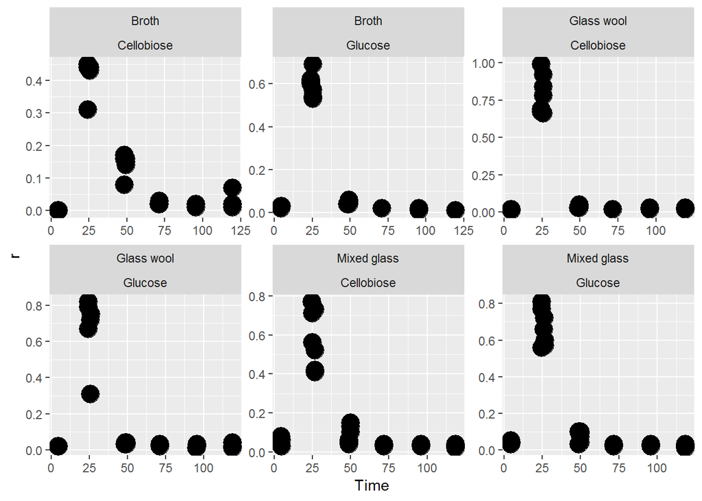

```r
#removing outliers
#respiration rate
ggplot(d, aes(Time, r))+geom_point(cex=6)+facet_wrap(Structure~Substrate, scales="free")
```

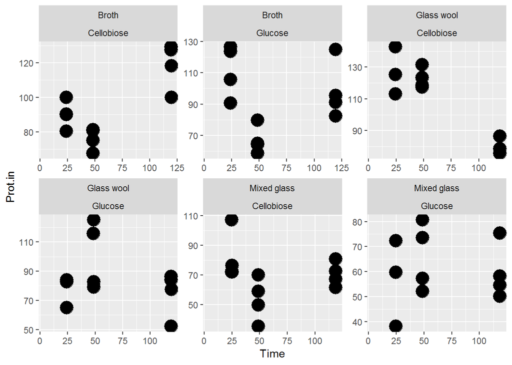

```r
d[(d$Substrate=="Glucose" & d$Structure=="Glass wool" & d$Time>20 & d$Time<30 & d$r<0.4 & !is.na(d$r)), "r"]<-NA

#Proteins
ggplot(d, aes(Time, Prot.in))+geom_point(cex=6)+facet_wrap(Structure~Substrate, scales="free")
```

```r
d[(d$Substrate=="Cellobiose" & d$Structure=="Broth" &  d$Time>75), "Prot.in"]<-NA
d[(d$Substrate=="Glucose" & d$Structure=="Broth" & d$Time>75), "Prot.in"]<-NA
d[(d$Substrate=="Cellobiose" & d$Structure=="Mixed glass" & d$Time>75), "Prot.in"]<-NA
d[(d$Substrate=="Cellobiose" & d$Structure=="Glass wool" & d$Time>75 & d$Prot.in>110 & !is.na(d$Prot.in)), "Prot.in"]<-NA
```

DNA and protein concentrations are in $\mu$grams per incubation vial. Both values are recalculated to unit of carbon per one ml of media in the vial (4 ml) using the conversion factors reported in Vrede et al. (2004).

```r
d$Protc<-d$Prot.in*0.46/12.01/4
d$DNAc<-d$DNA*0.51/12.01/4
```

## Statistical analysis

Linear Mixed-Effect models are used to evaluate the effect of substrate and the type of physical barrier on measured respiration rate, DNA and protein concentration. Becuase all three variables display significant variability over time, the time of measurement is treated as a random effect. Type of the barrier is nested within the substrate.

**Table S1:** Results of linear mixed-effects model analysis. Effect of substrate, the type physical barrier (Structure) and their interaction was evaluated. Statistical analysis was conducted for measured respiration rate, cellular protien concentration and DNA. F values, degrees of freedom (df) and the probabality (p) are reported.

|  | Respiration rate F | Respiration rate df | Respiration rate p | Cellular Proteins F | Cellular Proteins df | Cellular Proteins p | DNA F | DNA df | DNA p |
| --- | --- | --- | --- | --- | --- | --- | --- | --- | --- |
| Substrate | 0.11 | 1 | 0.743 | 0.33 | 1 | 0.566 | 0.33 | 1 | 0.566 |
| Structure | 6.26 | 2 | 0.002 | 18.96 | 2 | 0.000 | 18.96 | 2 | 0.000 |
| Substrate*Structure | 1.08 | 2 | 0.342 | 0.44 | 2 | 0.647 | 0.44 | 2 | 0.647 |

$~$ $~$ $~$ $~$ $~$ $~$

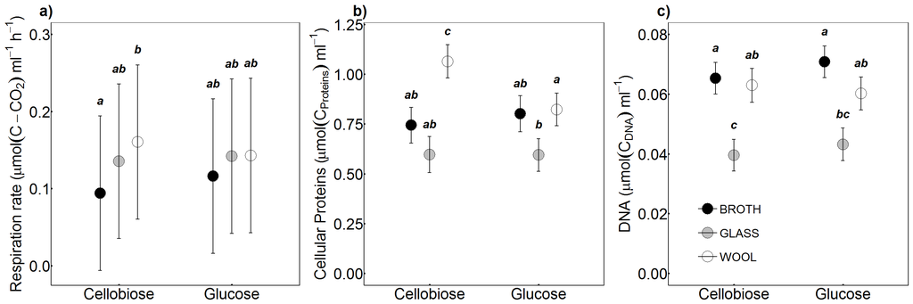

Fig. S1: Marginal effects of the substrate (Glucose or Cellobiose) and the type of physical barrier (BROTH, GLASS, WOOL) on the respiration rate (a), cellular proteins (b) and DNA concentration (c) estimated by the linear mixed-effect model.

## Microbial-explicit models analysis

### All models are first calibrated against respiration rate

Calibration of each model is done in four steps. First, the model is calibrated against data across all treatments. Second, the model is calibrated for each level of incubation system complexity separately. Third, the model is calibrated for Glucose and Cellobiose treatments separately. Fourth, the model is calibrated for each experimental treatment separately. Goodness of correspondence between measurements and model simulations are calculated across all treatments. By doing so, the effect of experimental treatment is evaluated. If the model simulation fits the data significantly better when model parameters are estimated for different treatments separately, effect of this treatment is significant.

The calibration of the models is not run within this document because it takes couple of hours to finish. Results of the previous iteration is printed instead. To run the code and reproduce the results, the option “eval” need to be changed to TRUE. Please note that the parallel computing is used. Number of cores is set to total number of cores of the computer minus 1. This can be changed if necessary.

#### Monod model

```r
monod_r<-function(data, FACT){

  #FACT 1 = Substrate, 2=Structure, 3=Both, 4=No

  if(FACT==1){

    dat<-data
    dat$id<-ifelse(data$Substrate=="Glucose", 1, 2)

  }else{

    if(FACT==2){

      dat<-data
      dat<-data
      ids<-dat %>% group_by(Structure) %>% summarise(id=n())
      ids$id<-seq(1:nrow(ids))

      dat<-merge(dat, ids, by.x=c("Structure"), by.y=c("Structure"))

    }else{

      if(FACT==3){

        dat<-data
        ids<-dat %>% group_by(Substrate, Structure) %>% summarise(id=n())
        ids$id<-seq(1:nrow(ids))

        dat<-merge(dat, ids, by.x=c("Substrate","Structure"), by.y=c("Substrate", "Structure"))


      }else{

        dat<-data
        dat$id<-c(1)

      }
    }
  }


    #monod growth function
    deriv<-function(time, state, pars){

      with(as.list(c(state, pars)),{

        dCmic<--k*Cmic+CUE*Vmax*Cmic*C/(Km+C)
        dC<-k*Cmic-Vmax*Cmic*C/(Km+C)

        return(list(c(dCmic, dC), r=(1-CUE)*Vmax*Cmic*C/(Km+C), Protc=0.548*Cmic))

      })
    }

    #define names of parameters
    parnames<-c("Vmax", "Km", "CUE", "k", "Cmic_0")

    #parameters estimation function
    estim<-function(odeset){

      #defining cost function
      cost<-function(x){

        par<-x[1:length(parnames)]

        names(par)<-parnames

        #first, pars dependent output from ode is matched with measured values
        yhat_all<-as.data.frame(ode(y=c(Cmic=par[["Cmic_0"]], C=25), parms=par, deriv, times=sort(odeset$Time)))

        #select time and the measured variables
        yhat<-select(yhat_all, c("time", "r", "Protc"))

        #reformat to long format data frame
        Yhat<-melt(yhat, id.vars = "time")

        #add the measured data to a data frame
        Yhat$obs<-c(odeset[order(odeset$Time), c("r")], odeset[order(odeset$Time), "Protc"])

        #add the weighting factor
        #I want to have the weighting factor to be proportional to mean of the given variable
        yweights<-Yhat %>% group_by(variable) %>% summarise(weights=mean(value, na.rm = T))

        #match with the Yhat data frame
        Yhat<-merge(Yhat, yweights, by.x=c("variable"), by.y=c("variable"))

        Yhat<-Yhat[Yhat$variable!="Protc", ]

        #now, the root mean square error is calculated
        NRMSE<-as.numeric(Yhat %>% summarise(NRMSE=sum((((value-obs)/mean(weights))^2), na.rm = T)))

        return(NRMSE)

      }

      #defining goodness of fit function
      rsq_ode<-function(x){

        par<-x[1:length(parnames)]

        names(par)<-parnames

        #first, pars dependent output from ode is matched with measured values
        yhat_all<-as.data.frame(ode(y=c(Cmic=par[["Cmic_0"]], C=25), parms=par, deriv, times=sort(odeset$Time)))

        #select time and the measured variables
        yhat<-select(yhat_all, c("time", "r", "Protc"))

        #reformat to long format data frame
        Yhat<-melt(yhat, id.vars = "time")

        #add the measured data to a data frame
        Yhat$obs<-c(odeset[order(odeset$Time), c("r")], odeset[order(odeset$Time), "Protc"])
        Yhat$Substrate<-rep(odeset[order(odeset$Time), "Substrate"], times=2)
        Yhat$Structure<-rep(odeset[order(odeset$Time), "Structure"], times=2)

        #rsquared calculation for each variable
        Gfit<-Yhat %>% group_by(variable) %>% summarise(SSres=sum(((obs-value)^2), na.rm = T),
                                                        SStot=sum(((obs-mean(obs, na.rm = T))^2), na.rm = T),
                                                        ll=-sum(((obs-value)^2), na.rm = T)/2/(sd(obs, na.rm = T)^2))
        Gfit$R2<-with(Gfit, 1-SSres/SStot)
        Gfit$N<-c(5)
        Gfit$AIC<-with(Gfit, 2*N-2*ll)

        rsq_out<-list(Yhat=Yhat, Gfit=Gfit)

        return(rsq_out)

      }

      #approximate parameter estimation is done by MCMC method
      par_mcmc<-modMCMC(f=cost, p=c(Vmax=0.1, Km=3, CUE=0.5, k=1e-3, Cmic_0=0.01),
                        lower=c(Vmax=1e-6, Km=1e-3, CUE=0, k=1e-6, Cmic_0=0.0001),
                        upper=c(Vmax=10, Km=100, CUE=1, k=10, Cmic_0=10), niter=10000)

      #lower and upper limits for parameters are extracted
      pl<-summary(par_mcmc)["min",]
      pu<-summary(par_mcmc)["max",]

      #these limits are used to find global optimum by DEoptim
      opt_par<-DEoptim(fn=cost, lower=pl, upper=pu,
                       control = c(itermax = 10000, steptol = 50, reltol = 1e-8,
                                   trace=FALSE, strategy=3, NP=250))

      #global optimum parameters are further used in MCMC to find parameters distribution
      par_prof<-modMCMC(f=cost, p=opt_par$optim$bestmem,
                        lower=pl,
                        upper=pu, niter=5000)

      #goodness of fit
      fit<-rsq_ode(opt_par$optim$bestmem)

      #best parameters
      p<-opt_par$optim$bestmem
      names(p)<-parnames

      #return list with opt_par and par_prof
      estim_out<-list(pars=p, par_prof=par_prof, fit=fit)

      return(estim_out)

    }


    #parameter estimation
    if(FACT==4){

      res<-vector("list", length = 1)
      res[[1]]<-estim(odeset=dat)

    }else{

      res<-foreach(i=unique(dat$id), .combine=list, .multicombine = TRUE,
                   .packages=c("FME", "dplyr", "DEoptim", "reshape")) %dopar% {

                     estim(odeset=dat[dat$id==i,])

                   }
    }


    #calculation of overall goodness of fit from individual results
    if(FACT==4){

      res$goodness<-res[[1]]$fit$Gfit
      res$OvP<-res[[1]]$fit$Yhat

    }else{

      if(FACT==1){

        res$OvP<-rbind(res[[1]]$fit$Yhat, res[[2]]$fit$Yhat)

        #rsquared calculation for each variable
        res$goodness<-res$OvP %>% group_by(variable) %>% summarise(SSres=sum(((obs-value)^2), na.rm = T),
                                                                   SStot=sum(((obs-mean(obs, na.rm = T))^2), na.rm = T),
                                                                   ll=-sum(((obs-value)^2), na.rm = T)/2/(sd(obs, na.rm = T)^2))
        res$goodness$R2<-with(res$goodness, 1-SSres/SStot)
        res$goodness$N<-rep(length(parnames)*2, times=2)
        res$goodness$AIC<-with(res$goodness, 2*N-2*ll)


      }else{

        if(FACT==2){

          res$OvP<-rbind(res[[1]]$fit$Yhat, res[[2]]$fit$Yhat, res[[3]]$fit$Yhat)

          #rsquared calculation for each variable
          res$goodness<-res$OvP %>% group_by(variable) %>% summarise(SSres=sum(((obs-value)^2), na.rm = T),
                                                                     SStot=sum(((obs-mean(obs, na.rm = T))^2), na.rm = T),
                                                                     ll=-sum(((obs-value)^2), na.rm = T)/2/(sd(obs, na.rm = T)^2))
          res$goodness$R2<-with(res$goodness, 1-SSres/SStot)
          res$goodness$N<-rep(length(parnames)*3, times=2)
          res$goodness$AIC<-with(res$goodness, 2*N-2*ll)

        }else{

          res$OvP<-rbind(res[[1]]$fit$Yhat, res[[2]]$fit$Yhat, res[[3]]$fit$Yhat, res[[4]]$fit$Yhat, res[[5]]$fit$Yhat, res[[6]]$fit$Yhat)

          #rsquared calculation for each variable
          res$goodness<-res$OvP %>% group_by(variable) %>% summarise(SSres=sum(((obs-value)^2), na.rm = T),
                                                                     SStot=sum(((obs-mean(obs, na.rm = T))^2), na.rm = T),
                                                                     ll=-sum(((obs-value)^2), na.rm = T)/2/(sd(obs, na.rm = T)^2))
          res$goodness$R2<-with(res$goodness, 1-SSres/SStot)
          res$goodness$N<-rep(length(parnames)*6, times=2)
          res$goodness$AIC<-with(res$goodness, 2*N-2*ll)

        }

      }

    }

    return(res)


}
```

```r
#across all treatments
monod_r1<-monod_r(data=d, FACT = 4)

no_cors<-detectCores()-1
cl<-makeCluster(no_cors)
registerDoParallel(cl)

#for different structures
monod_r2<-monod_r(data=d, FACT = 2)

#for different substrates
monod_r3<-monod_r(data=d, FACT = 1)

#for each separately
monod_r4<-monod_r(data=d, FACT = 3)

stopImplicitCluster()

monod_r1$goodness
monod_r2$goodness
monod_r3$goodness
monod_r4$goodness
```

**Table S2:** Monod model parameters calibrated against respiration rate across all treatments (All), for different levels of incubation system complexity separately (Structure), for Glucose and Celluloze treatments separately (Substrate), and for all experimental treatments separatelly (Each). See Materials and Methods for symbols explanation.

|  | $\V_{MAX}$ | $\K_{M}$ | CUE | $\k_{MB}$ |
| --- | --- | --- | --- | --- |
| **All** |  |  |  |  |
| All | 0.50 | 12.36 | 0.72 | 0.011 |
| **Structure** |  |  |  |  |
| Broth | 0.56 | 13.32 | 0.81 | 0.007 |
| Glass | 0.56 | 13.45 | 0.66 | 0.003 |
| Wool | 0.47 | 8.50 | 0.74 | 0.009 |
| **Substrate** |  |  |  |  |
| Cellobiose | 1.11 | 19.60 | 0.21 | 0.005 |
| Glucose | 0.93 | 36.45 | 0.64 | 0.009 |
| **Each** |  |  |  |  |
| Broth - Cellobiose | 0.91 | 33.56 | 0.38 | 0.007 |
| Broth - Glucose | 0.74 | 20.33 | 0.65 | 0.010 |
| Glass - Cellobiose | 0.97 | 32.05 | 0.62 | 0.007 |
| Glass - Glucose | 0.71 | 23.93 | 0.73 | 0.005 |
| Wool - Cellobiose | 0.71 | 22.19 | 0.64 | 0.006 |
| Wool - Glucose | 1.23 | 51.55 | 0.57 | 0.007 |

**Table S3:** Goodness of fit of monod model calibrated against respiration rate across all treatments (All), for different levels of incubation system complexity separately (Structure), for Glucose and Celluloze treatments separately (Substrate), and for all experimental treatments separatelly (Each). See Materials and Methods for symbols explanation.

| Log Likelihood | $\R^{2}$ | Number of parameters | AIC |
| --- | --- | --- | --- |
| **All** |  |  |  |
| -8.44 | 0.91 | 5 | 26.87 |
| **Structure** |  |  |  |
| -4.62 | 0.95 | 15 | 39.24 |
| **Substrate** |  |  |  |
| -8.23 | 0.91 | 10 | 36.47 |
| **Each** |  |  |  |
| -2.76 | 0.97 | 30 | 65.53 |

#### MEND model

```r
mend_r<-function(data, FACT){

  #FACT 1 = Substrate, 2=Structure, 3=Both, 4=No

  if(FACT==1){

    dat<-data
    dat$id<-ifelse(d$Substrate=="Glucose", 1, 2)

  }else{

    if(FACT==2){

      dat<-data
      dat<-data
      ids<-dat %>% group_by(Structure) %>% summarise(id=n())
      ids$id<-seq(1:nrow(ids))

      dat<-merge(dat, ids, by.x=c("Structure"), by.y=c("Structure"))

    }else{

      if(FACT==3){

        dat<-data
        ids<-dat %>% group_by(Substrate, Structure) %>% summarise(id=n())
        ids$id<-seq(1:nrow(ids))

        dat<-merge(dat, ids, by.x=c("Substrate","Structure"), by.y=c("Substrate", "Structure"))


      }else{

        dat<-data
        dat$id<-c(1)

      }
    }
  }

    #mend model
    deriv<-function(time, state, pars){

      with(as.list(c(state, pars)),{

        #equations
        #C uptake
        F1=1/CUE*(Vmax+mr)*Cmic*C/(Km+C)
        #growth respiration
        F4=(1/CUE-1)*Vmax*Cmic*C/(Km+C)
        #maintnance respiration
        F5=(1/CUE-1)*mr*Cmic*C/(Km+C)
        #microbial mortality
        F8=mr*Cmic

        #states
        dCmic<-F1-(F4+F5)-F8
        dC<--F1+F8

        return(list(c(dCmic, dC), r=F4+F5, Protc=0.548*Cmic))

      })
    }
    #define names of parameters
    parnames<-c("Vmax", "Km", "CUE", "mr", "Cmic_0")

    #parameters estimation function
    estim<-function(odeset){

      #defining cost function
      cost<-function(x){

        par<-x[1:length(parnames)]

        names(par)<-parnames

        #first, pars dependent output from ode is matched with measured values
        yhat_all<-as.data.frame(ode(y=c(Cmic=par[["Cmic_0"]], C=25), parms=par, deriv, times=sort(odeset$Time)))

        #select time and the measured variables
        yhat<-select(yhat_all, c("time", "Protc", "r"))

        #reformat to long format data frame
        Yhat<-melt(yhat, id.vars = "time")

        #add the measured data to a data frame
        Yhat$obs<-c(odeset[order(odeset$Time), "Protc"], odeset[order(odeset$Time), c("r")])

        #add the weighting factor
        #I want to have the weighting factor to be proportional to mean of the given variable
        yweights<-Yhat %>% group_by(variable) %>% summarise(weights=mean(value, na.rm = T))

        #match with the Yhat data frame
        Yhat<-merge(Yhat, yweights, by.x=c("variable"), by.y=c("variable"))

        Yhat<-Yhat[Yhat$variable!="Protc", ]

        #now, the root mean square error is calculated
        NRMSE<-as.numeric(Yhat %>% summarise(NRMSE=sum((((value-obs)/mean(weights))^2), na.rm = T)))

        return(NRMSE)

      }

      #defining goodness of fit function
      rsq_ode<-function(x){

        par<-x[1:length(parnames)]

        names(par)<-parnames

        #first, pars dependent output from ode is matched with measured values
        yhat_all<-as.data.frame(ode(y=c(Cmic=par[["Cmic_0"]], C=25), parms=par, deriv, times=sort(odeset$Time)))

        #select time and the measured variables
        yhat<-select(yhat_all, c("time", "Protc", "r"))

        #reformat to long format data frame
        Yhat<-melt(yhat, id.vars = "time")

        #add the measured data to a data frame
        Yhat$obs<-c(odeset[order(odeset$Time), "Protc"], odeset[order(odeset$Time), c("r")])
        Yhat$Substrate<-rep(odeset[order(odeset$Time), "Substrate"], times=2)
        Yhat$Structure<-rep(odeset[order(odeset$Time), "Structure"], times=2)

        #rsquared calculation for each variable
        Gfit<-Yhat %>% group_by(variable) %>% summarise(SSres=sum(((obs-value)^2), na.rm = T),
                                                        SStot=sum(((obs-mean(obs, na.rm = T))^2), na.rm = T),
                                                        ll=-sum(((obs-value)^2), na.rm = T)/2/(sd(obs, na.rm = T)^2))
        Gfit$R2<-with(Gfit, 1-SSres/SStot)
        Gfit$N<-c(5)
        Gfit$AIC<-with(Gfit, 2*N-2*ll)

        rsq_out<-list(Yhat=Yhat, Gfit=Gfit)

        return(rsq_out)

      }

      #approximate parameter estimation is done by MCMC method
      par_mcmc<-modMCMC(f=cost, p=c(Vmax=0.1, Km=3, CUE=0.5, mr=0.01, Cmic_0=0.01),
                          lower=c(Vmax=1e-3, Km=1e-3, CUE=0, mr=1e-5,  Cmic_0=1e-5),
                          upper=c(Vmax=10, Km=100, CUE=1, mr=10, Cmic_0=5), niter=10000)

      #lower and upper limits for parameters are extracted
      pl<-summary(par_mcmc)["min",]
      pu<-summary(par_mcmc)["max",]

      #these limits are used to find global optimum by DEoptim
      opt_par<-DEoptim(fn=cost, lower=pl, upper=pu,
                       control = c(itermax = 10000, steptol = 50, reltol = 1e-8,
                                   trace=FALSE, strategy=3, NP=250))

      #global optimum parameters are further used in MCMC to find parameters distribution
      par_prof<-modMCMC(f=cost, p=opt_par$optim$bestmem,
                        lower=pl,
                        upper=pu, niter=5000)

      #goodness of fit
      fit<-rsq_ode(opt_par$optim$bestmem)

      #best parameters
      p<-opt_par$optim$bestmem
      names(p)<-parnames

      #return list with opt_par and par_prof
      estim_out<-list(pars=p, par_prof=par_prof, fit=fit)

      return(estim_out)

    }


    #parameter estimation
    if(FACT==4){

      res<-vector("list", length = 1)
      res[[1]]<-estim(odeset=dat)

    }else{

      res<-foreach(i=unique(dat$id), .combine=list, .multicombine = TRUE,
                   .packages=c("FME", "dplyr", "DEoptim", "reshape")) %dopar% {

                     estim(odeset=dat[dat$id==i,])

                   }
    }


    #calculation of overall goodness of fit from individual results
    if(FACT==4){

      res$goodness<-res[[1]]$fit$Gfit
      res$OvP<-res[[1]]$fit$Yhat

    }else{

      if(FACT==1){

        res$OvP<-rbind(res[[1]]$fit$Yhat, res[[2]]$fit$Yhat)

        #rsquared calculation for each variable
        res$goodness<-res$OvP %>% group_by(variable) %>% summarise(SSres=sum(((obs-value)^2), na.rm = T),
                                                               SStot=sum(((obs-mean(obs, na.rm = T))^2), na.rm = T),
                                                               ll=-sum(((obs-value)^2), na.rm = T)/2/(sd(obs, na.rm = T)^2))
        res$goodness$R2<-with(res$goodness, 1-SSres/SStot)
        res$goodness$N<-rep(length(parnames)*2, times=2)
        res$goodness$AIC<-with(res$goodness, 2*N-2*ll)


      }else{

        if(FACT==2){

          res$OvP<-rbind(res[[1]]$fit$Yhat, res[[2]]$fit$Yhat, res[[3]]$fit$Yhat)

          #rsquared calculation for each variable
          res$goodness<-res$OvP %>% group_by(variable) %>% summarise(SSres=sum(((obs-value)^2), na.rm = T),
                                                                 SStot=sum(((obs-mean(obs, na.rm = T))^2), na.rm = T),
                                                                 ll=-sum(((obs-value)^2), na.rm = T)/2/(sd(obs, na.rm = T)^2))
          res$goodness$R2<-with(res$goodness, 1-SSres/SStot)
          res$goodness$N<-rep(length(parnames)*3, times=2)
          res$goodness$AIC<-with(res$goodness, 2*N-2*ll)

        }else{

          res$OvP<-rbind(res[[1]]$fit$Yhat, res[[2]]$fit$Yhat, res[[3]]$fit$Yhat, res[[4]]$fit$Yhat, res[[5]]$fit$Yhat, res[[6]]$fit$Yhat)

          #rsquared calculation for each variable
          res$goodness<-res$OvP %>% group_by(variable) %>% summarise(SSres=sum(((obs-value)^2), na.rm = T),
                                                                 SStot=sum(((obs-mean(obs, na.rm = T))^2), na.rm = T),
                                                                 ll=-sum(((obs-value)^2), na.rm = T)/2/(sd(obs, na.rm = T)^2))
          res$goodness$R2<-with(res$goodness, 1-SSres/SStot)
          res$goodness$N<-rep(length(parnames)*6, times=2)
          res$goodness$AIC<-with(res$goodness, 2*N-2*ll)

        }

      }

    }

  return(res)

}
```

```r
#across all treatments
mend_r1<-mend_r(data=d, FACT = 4)

no_cors<-detectCores()-1
cl<-makeCluster(no_cors)
registerDoParallel(cl)

#for different structures
mend_r2<-mend_r(data=d, FACT = 2)

#for different substrates
mend_r3<-mend_r(data=d, FACT = 1)

#for each separately
mend_r4<-mend_r(data=d, FACT = 3)

stopImplicitCluster()

mend_r1$goodness
mend_r2$goodness
mend_r3$goodness
mend_r4$goodness
```

**Table S4:** MEND model parameters calibrated against respiration rate across all treatments (All), for different levels of incubation system complexity separately (Structure), for Glucose and Celluloze treatments separately (Substrate), and for all experimental treatments separatelly (Each). See Materials and Methods for symbols explanation.

|  | $\V_{MAX}$ | $\K_{M}$ | CUE | $\m_{R}$ |
| --- | --- | --- | --- | --- |
| **All** |  |  |  |  |
| All | 0.34 | 8.40 | 0.77 | 0.022 |
| **Structure** |  |  |  |  |
| Broth | 0.32 | 0.58 | 0.90 | 0.040 |
| Glass | 0.34 | 10.00 | 0.69 | 0.009 |
| Wool | 0.13 | 7.52 | 0.04 | 0.022 |
| **Substrate** |  |  |  |  |
| Celluloze | 0.32 | 4.48 | 0.82 | 0.042 |
| Glucose | 0.38 | 10.00 | 0.76 | 0.011 |
| **Each** |  |  |  |  |
| Broth - Cellobiose | 0.65 | 2.51 | 0.61 | 0.118 |
| Broth - Glucose | 0.36 | 9.99 | 0.71 | 0.011 |
| Glass - Cellobiose | 0.39 | 9.99 | 0.76 | 0.025 |
| Glass - Glucose | 0.30 | 0.35 | 0.87 | 0.013 |
| Wool - Cellobiose | 0.32 | 10.00 | 0.69 | 0.006 |
| Wool - Glucose | 0.40 | 10.00 | 0.76 | 0.014 |

**Table S5:** Goodness of fit of MEND model calibrated against respiration rate across all treatments (All), for different levels of incubation system complexity separately (Structure), for Glucose and Celluloze treatments separately (Substrate), and for all experimental treatments separatelly (Each). See Materials and Methods for symbols explanation.

| Log Likelihood | $\R^{2}$ | Number of parameters | AIC |
| --- | --- | --- | --- |
| **All** |  |  |  |
| -9.28 | 0.90 | 5 | 28.57 |
| **Structure** |  |  |  |
| -6.09 | 0.93 | 15 | 42.18 |
| **Substrate** |  |  |  |
| -9.05 | 0.90 | 10 | 38.11 |
| **Each** |  |  |  |
| -2.88 | 0.97 | 30 | 65.76 |

#### DEB model

```r
deb_r<-function(data, FACT){

  #FACT 1 = Substrate, 2=Structure, 3=Both, 4=No


  #if factor needs to be included, its levels are defined
  if(FACT==1){

    dat<-data
    dat$id<-ifelse(data$Substrate=="Glucose", 1, 2)

  }else{

    if(FACT==2){

      dat<-data
      dat<-data
      ids<-dat %>% group_by(Structure) %>% summarise(id=n())
      ids$id<-seq(1:nrow(ids))

      dat<-merge(dat, ids, by.x=c("Structure"), by.y=c("Structure"))

    }else{

      if(FACT==3){

        dat<-data
        ids<-dat %>% group_by(Substrate, Structure) %>% summarise(id=n())
        ids$id<-seq(1:nrow(ids))

        dat<-merge(dat, ids, by.x=c("Substrate","Structure"), by.y=c("Substrate", "Structure"))

      }else{

        dat<-data
        dat$id<-c(1)

      }
    }
  }

    #deb model
    deriv<-function(time, state, pars){

      with(as.list(c(state, pars)),{

        #Carbon uptake
        Cu=Vmax*C*S/(Km+C)

        #maintnance
        m=S*m0

        #reserve mobilization rate for growth
        an=f*R-m

        #calibrated variables
        #protein abundance in reserves and structures is mean value reported
        #by Hanegraaf and Muller, 2001
        r=m+pmax(an*(1-Yu), 0)

        Protc=0.7095*S+0.6085*R
        #Protc=fps*S+fpr*R

        dR<-Cu-f*R
        dS<-pmax(an*Yu,0)+pmin(0, an)
        dC<--Cu

        return(list(c(dR, dS, dC), r=r, Protc=Protc))

      })
    }
    #define names of parameters
    parnames<-c("Vmax", "Km", "m0", "f", "Yu", "R_0", "S_0")

    #parameters estimation function
    estim<-function(odeset){

      #defining cost function
      cost<-function(x){

        par<-x[1:length(parnames)]

        names(par)<-parnames

        #first, pars dependent output from ode is matched with measured values
        yhat_all<-as.data.frame(ode(y=c(R=par[["R_0"]], S=par[["S_0"]], C=25), parms=par, deriv, times=sort(odeset$Time)))

        #select time and the measured variables
        yhat<-select(yhat_all, c("time", "r", "Protc"))

        #reformat to long format data frame
        Yhat<-melt(yhat, id.vars = "time")

        #add the measured data to a data frame
        Yhat$obs<-c(odeset[order(odeset$Time), c("r")], odeset[order(odeset$Time), "Protc"])

        #add the weighting factor
        #I want to have the weighting factor to be proportional to mean of the given variable
        yweights<-Yhat %>% group_by(variable) %>% summarise(weights=mean(value, na.rm = T))

        #match with the Yhat data frame
        Yhat<-merge(Yhat, yweights, by.x=c("variable"), by.y=c("variable"))

        Yhat<-Yhat[Yhat$variable!="Protc", ]

        #now, the root mean square error is calculated
        NRMSE<-as.numeric(Yhat %>% summarise(NRMSE=sum((((value-obs)/mean(weights))^2), na.rm = T)))

        return(NRMSE)

      }

      #defining goodness of fit function
      rsq_ode<-function(x){

        par<-x[1:length(parnames)]

        names(par)<-parnames

        #first, pars dependent output from ode is matched with measured values
        yhat_all<-as.data.frame(ode(y=c(R=par[["R_0"]], S=par[["S_0"]], C=25), parms=par, deriv, times=sort(odeset$Time)))

        #select time and the measured variables
        yhat<-select(yhat_all, c("time", "r", "Protc"))

        #reformat to long format data frame
        Yhat<-melt(yhat, id.vars = "time")

        #add the measured data to a data frame
        Yhat$obs<-c(odeset[order(odeset$Time), c("r")], odeset[order(odeset$Time), "Protc"])
        Yhat$Substrate<-rep(odeset[order(odeset$Time), "Substrate"], times=2)
        Yhat$Structure<-rep(odeset[order(odeset$Time), "Structure"], times=2)

        #rsquared calculation for each variable
        Gfit<-Yhat %>% group_by(variable) %>% summarise(SSres=sum(((obs-value)^2), na.rm = T),
                                                        SStot=sum(((obs-mean(obs, na.rm = T))^2), na.rm = T),
                                                        ll=-sum(((obs-value)^2), na.rm = T)/2/(sd(obs, na.rm = T)^2))
        Gfit$R2<-with(Gfit, 1-SSres/SStot)
        Gfit$N<-c(7)
        Gfit$AIC<-with(Gfit, 2*N-2*ll)

        rsq_out<-list(Yhat=Yhat, Gfit=Gfit)

        return(rsq_out)

      }

      #approximate parameter estimation is done by MCMC method
      par_mcmc<-modMCMC(f=cost, p=c(Vmax=0.1, Km=3, m0=0.01, f=4, Yu=0.8,R_0=0.03483481, S_0=0.07661063),
                          lower=c(Vmax=1e-5, Km=1e-2, m0=1e-5, f=1e-3, Yu=0.01, R_0=1e-4, S_0=1e-4),
                          upper=c(Vmax=1, Km=20, m0=1, f=100, Yu=0.8, R_0=2, S_0=2), niter=10000)

      #lower and upper limits for parameters are extracted
      pl<-summary(par_mcmc)["min",]
      pu<-summary(par_mcmc)["max",]

      #these limits are used to find global optimum by DEoptim
      opt_par<-DEoptim(fn=cost, lower=pl, upper=pu,
                       control = c(itermax = 10000, steptol = 50, reltol = 1e-8,
                                   trace=FALSE, strategy=3, NP=250))

      #global optimum parameters are further used in MCMC to find parameters distribution
      par_prof<-modMCMC(f=cost, p=opt_par$optim$bestmem,
                        lower=pl,
                        upper=pu, niter=5000)

      #goodness of fit
      fit<-rsq_ode(opt_par$optim$bestmem)

      #best parameters
      p<-opt_par$optim$bestmem
      names(p)<-parnames

      #return list with opt_par and par_prof
      estim_out<-list(pars=p, par_prof=par_prof, fit=fit)

      return(estim_out)

    }

    #parameter estimation
    if(FACT==4){

      res<-vector("list", length = 1)
      res[[1]]<-estim(odeset=dat)

    }else{

      res<-foreach(i=unique(dat$id), .combine=list, .multicombine = TRUE,
                   .packages=c("FME", "dplyr", "DEoptim", "reshape")) %dopar% {

                     estim(odeset=dat[dat$id==i,])

                   }
    }

    #calculation of overall goodness of fit from individual results
    if(FACT==4){

      res$goodness<-res[[1]]$fit$Gfit
      res$OvP<-res[[1]]$fit$Yhat

    }else{

      if(FACT==1){

        res$OvP<-rbind(res[[1]]$fit$Yhat, res[[2]]$fit$Yhat)

        #rsquared calculation for each variable
        res$goodness<-res$OvP %>% group_by(variable) %>% summarise(SSres=sum(((obs-value)^2), na.rm = T),
                                                               SStot=sum(((obs-mean(obs, na.rm = T))^2), na.rm = T),
                                                               ll=-sum(((obs-value)^2), na.rm = T)/2/(sd(obs, na.rm = T)^2))
        res$goodness$R2<-with(res$goodness, 1-SSres/SStot)
        res$goodness$N<-rep(length(parnames)*2, times=2)
        res$goodness$AIC<-with(res$goodness, 2*N-2*ll)

      }else{

        if(FACT==2){

          res$OvP<-rbind(res[[1]]$fit$Yhat, res[[2]]$fit$Yhat, res[[3]]$fit$Yhat)

          #rsquared calculation for each variable
          res$goodness<-res$OvP %>% group_by(variable) %>% summarise(SSres=sum(((obs-value)^2), na.rm = T),
                                                                 SStot=sum(((obs-mean(obs, na.rm = T))^2), na.rm = T),
                                                                 ll=-sum(((obs-value)^2), na.rm = T)/2/(sd(obs, na.rm = T)^2))
          res$goodness$R2<-with(res$goodness, 1-SSres/SStot)
          res$goodness$N<-rep(length(parnames)*3, times=2)
          res$goodness$AIC<-with(res$goodness, 2*N-2*ll)

        }else{

          res$OvP<-rbind(res[[1]]$fit$Yhat, res[[2]]$fit$Yhat, res[[3]]$fit$Yhat, res[[4]]$fit$Yhat, res[[5]]$fit$Yhat, res[[6]]$fit$Yhat)

          #rsquared calculation for each variable
          res$goodness<-res$OvP %>% group_by(variable) %>% summarise(SSres=sum(((obs-value)^2), na.rm = T),
                                                                 SStot=sum(((obs-mean(obs, na.rm = T))^2), na.rm = T),
                                                                 ll=-sum(((obs-value)^2), na.rm = T)/2/(sd(obs, na.rm = T)^2))
          res$goodness$R2<-with(res$goodness, 1-SSres/SStot)
          res$goodness$N<-rep(length(parnames)*6, times=2)
          res$goodness$AIC<-with(res$goodness, 2*N-2*ll)

        }

      }

    }

  return(res)

}
```

```r
#across all treatments
deb_r1<-deb_r(data=d, FACT = 4)

no_cors<-detectCores()-1
cl<-makeCluster(no_cors)
registerDoParallel(cl)

#for different structures
deb_r2<-deb_r(data=d, FACT = 2)

#for different substrates
deb_r3<-deb_r(data=d, FACT = 1)

#for each separately
deb_r4<-deb_r(data=d, FACT = 3)

stopImplicitCluster()

deb_r1$goodness
deb_r2$goodness
deb_r3$goodness
deb_r4$goodness
```

**Table S6:** DEB model parameters calibrated against respiration rate across all treatments (All), for different levels of incubation system complexity separately (Structure), for Glucose and Celluloze treatments separately (Substrate), and for all experimental treatments separatelly (Each). See Materials and Methods for symbols explanation.

|  | $\V_{MAX}$ | $\K_{M}$ | $\m_{R}$ | $\f_{0}$ | $\Y_{S}$ |
| --- | --- | --- | --- | --- | --- |
| **All** |  |  |  |  |  |
| All | 0.31 | 4.86 | 0.006 | 5.03 | 0.73 |
| **Structure** |  |  |  |  |  |
| Broth | 0.82 | 2.83 | 0.059 | 6.36 | 0.39 |
| Glass | 0.55 | 15.41 | 0.003 | 4.25 | 0.59 |
| Wool | 0.56 | 17.65 | 0.006 | 11.22 | 0.59 |
| **Substrate** |  |  |  |  |  |
| Cellobiose | 0.39 | 5.13 | 0.007 | 4.33 | 0.80 |
| Glucose | 0.37 | 9.61 | 0.003 | 1.13 | 0.61 |
| **Each** |  |  |  |  |  |
| Broth - Cellobiose | 0.93 | 2.56 | 0.047 | 0.63 | 0.42 |
| Broth - Glucose | 0.73 | 18.36 | 0.004 | 0.58 | 0.51 |
| Glass - Cellobiose | 0.59 | 17.42 | 0.008 | 3.34 | 0.52 |
| Glass - Glucose | 0.45 | 17.44 | 0.002 | 4.32 | 0.62 |
| Wool - Cellobiose | 0.54 | 17.63 | 0.003 | 2.40 | 0.50 |
| Wool - Glucose | 0.53 | 18.16 | 0.005 | 5.05 | 0.51 |

**Table S7:** Goodness of fit of DEB model calibrated against respiration rate across all treatments (All), for different levels of incubation system complexity separately (Structure), for Glucose and Celluloze treatments separately (Substrate), and for all experimental treatments separatelly (Each). See Materials and Methods for symbols explanation.

| Log Likelihood | $\R^{2}$ | Number of parameters | AIC |
| --- | --- | --- | --- |
| **All** |  |  |  |
| -9.51 | 0.90 | 7 | 33.02 |
| **Structure** |  |  |  |
| -3.89 | 0.96 | 21 | 49.77 |
| **Substrate** |  |  |  |
| -9.22 | 0.90 | 14 | 46.44 |
| **Each** |  |  |  |
| -2.72 | 0.97 | 42 | 89.43 |

### All models are calibrated against respiration rate, proteins and DNA concentration

The calibration is done the same way as before. In addition to model parameters, the conversion factors between $C_{MB}$ (Monod and MEND model), $R$, $S$ (DEB model) and protein/DNA concetration are estimated. This is done for two reasons. First, conversion factors reported in literature vary widely. Second, using the mean or median of all reported conversion factors do not simulate $C_{MB}$, $R$ and $S$ dynamic accuratelly (data not shown). There is one important difference between Monod/MEND model and DEB model. Temporal dynamic of Proteins and DNA concentration is different (see Fig. 2 of the main text) suggesting the variable composition of microbial biomass. Monod and MEND models do not account for this variability and thus, conversion factor have to be a fixed value. However, model parameters can theoretically compansate for the variability in microbial biomass composition but only if the model is calibrated against protein or DNA separately. Becuase the temporal dynamic of protein and DNA is different, the compensation have to occur differently. In contrast, DEB model account for the biomass composition variability explicitely and therefore, it can be calibrated against protein and DNA concentration at the same time. The following code reflects this difference. Note that the calibration against respiration rate and protein/DNA concentration at the same time lead to a decrease of the the correspondence between Monod/MEND model respiration rate simulation and observations in several instances.

#### Monod model

```r
#######################################Proteins#############################################
monod_i<-function(data, FACT){

  #FACT 1 = Substrate, 2=Structure, 3=Both, 4=No

  if(FACT==1){

    dat<-data
    dat$id<-ifelse(data$Substrate=="Glucose", 1, 2)

  }else{

    if(FACT==2){

      dat<-data
      dat<-data
      ids<-dat %>% group_by(Structure) %>% summarise(id=n())
      ids$id<-seq(1:nrow(ids))

      dat<-merge(dat, ids, by.x=c("Structure"), by.y=c("Structure"))

    }else{

      if(FACT==3){

        dat<-data
        ids<-dat %>% group_by(Substrate, Structure) %>% summarise(id=n())
        ids$id<-seq(1:nrow(ids))

        dat<-merge(dat, ids, by.x=c("Substrate","Structure"), by.y=c("Substrate", "Structure"))


      }else{

        dat<-data
        dat$id<-c(1)

      }
    }
  }


    #monod growth function
    deriv<-function(time, state, pars){

      with(as.list(c(state, pars)),{

        Protc=fp*Cmic

        dCmic<--k*Cmic+CUE*Vmax*Cmic*C/(Km+C)
        dC<-k*Cmic-Vmax*Cmic*C/(Km+C)

        return(list(c(dCmic, dC), r=(1-CUE)*Vmax*Cmic*C/(Km+C), Protc=Protc))

      })
    }

    #define names of parameters
    parnames<-c("Vmax", "Km", "CUE", "k", "fp", "Cmic_0")

    #parameters estimation function
    estim<-function(odeset){

      #defining cost function
      cost<-function(x){

        par<-x[1:length(parnames)]

        names(par)<-parnames

        #first, pars dependent output from ode is matched with measured values
        yhat_all<-as.data.frame(ode(y=c(Cmic=par[["Cmic_0"]], C=25), parms=par, deriv, times=sort(odeset$Time)))

        #select time and the measured variables
        yhat<-select(yhat_all, c("time", "r", "Protc"))

        #reformat to long format data frame
        Yhat<-melt(yhat, id.vars = "time")

        #add the measured data to a data frame
        Yhat$obs<-c(odeset[order(odeset$Time), c("r")], odeset[order(odeset$Time), "Protc"])

        #add the weighting factor
        #I want to have the weighting factor to be proportional to mean of the given variable
        yweights<-Yhat %>% group_by(variable) %>% summarise(weights=mean(value, na.rm = T))

        #match with the Yhat data frame
        Yhat<-merge(Yhat, yweights, by.x=c("variable"), by.y=c("variable"))

        #now, the root mean square error is calculated
        NRMSE<-as.numeric(Yhat %>% group_by(variable) %>% summarise(NRMSE=sum((((value-obs)/mean(weights))^2), na.rm = T)) %>%
                            summarise(NRMSE=sum(NRMSE)))

        return(NRMSE)

      }

      #defining goodness of fit function
      rsq_ode<-function(x){

        par<-x[1:length(parnames)]

        names(par)<-parnames

        #first, pars dependent output from ode is matched with measured values
        yhat_all<-as.data.frame(ode(y=c(Cmic=par[["Cmic_0"]], C=25), parms=par, deriv, times=sort(odeset$Time)))

        #select time and the measured variables
        yhat<-select(yhat_all, c("time", "r", "Protc"))

        #reformat to long format data frame
        Yhat<-melt(yhat, id.vars = "time")

        #add the measured data to a data frame
        Yhat$obs<-c(odeset[order(odeset$Time), c("r")], odeset[order(odeset$Time), "Protc"])
        Yhat$Substrate<-rep(odeset[order(odeset$Time), "Substrate"], times=2)
        Yhat$Structure<-rep(odeset[order(odeset$Time), "Structure"], times=2)

        #rsquared calculation for each variable
        Gfit<-Yhat %>% group_by(variable) %>% summarise(SSres=sum(((obs-value)^2), na.rm = T),
                                                        SStot=sum(((obs-mean(obs, na.rm = T))^2), na.rm = T),
                                                        ll=-sum(((obs-value)^2), na.rm = T)/2/(sd(obs, na.rm = T)^2))
        Gfit$R2<-with(Gfit, 1-SSres/SStot)
        Gfit$N<-c(6)
        Gfit$AIC<-with(Gfit, 2*N-2*ll)

        rsq_out<-list(Yhat=Yhat, Gfit=Gfit)

        return(rsq_out)

      }

      #approximate parameter estimation is done by MCMC method
      par_mcmc<-modMCMC(f=cost, p=c(Vmax=0.1, Km=3, CUE=0.5, k=1e-3, fp=0.5, Cmic_0=0.01),
                        lower=c(Vmax=1e-6, Km=1e-3, CUE=0, k=1e-6, fp=0, Cmic_0=0.0001),
                        upper=c(Vmax=10, Km=100, CUE=1, k=10, fp=1, Cmic_0=10), niter=10000)

      #lower and upper limits for parameters are extracted
      pl<-summary(par_mcmc)["min",]
      pu<-summary(par_mcmc)["max",]

      #these limits are used to find global optimum by DEoptim
      opt_par<-DEoptim(fn=cost, lower=pl, upper=pu,
                       control = c(itermax = 10000, steptol = 50, reltol = 1e-8,
                                   trace=FALSE, strategy=3, NP=250))

      #global optimum parameters are further used in MCMC to find parameters distribution
      par_prof<-modMCMC(f=cost, p=opt_par$optim$bestmem,
                        lower=pl,
                        upper=pu, niter=5000)

      #goodness of fit
      fit<-rsq_ode(opt_par$optim$bestmem)

      #best parameters
      p<-opt_par$optim$bestmem
      names(p)<-parnames

      #return list with opt_par and par_prof
      estim_out<-list(pars=p, par_prof=par_prof, fit=fit)

      return(estim_out)

    }


    #parameter estimation
    if(FACT==4){

      res<-vector("list", length = 1)
      res[[1]]<-estim(odeset=dat)

    }else{

      res<-foreach(i=unique(dat$id), .combine=list, .multicombine = TRUE,
                   .packages=c("FME", "dplyr", "DEoptim", "reshape")) %dopar% {

                     estim(odeset=dat[dat$id==i,])

                   }
    }


    #calculation of overall goodness of fit from individual results
    if(FACT==4){

      res$goodness<-res[[1]]$fit$Gfit
      res$OvP<-res[[1]]$fit$Yhat

    }else{

      if(FACT==1){

        res$OvP<-rbind(res[[1]]$fit$Yhat, res[[2]]$fit$Yhat)

        #rsquared calculation for each variable
        res$goodness<-res$OvP %>% group_by(variable) %>% summarise(SSres=sum(((obs-value)^2), na.rm = T),
                                                                   SStot=sum(((obs-mean(obs, na.rm = T))^2), na.rm = T),
                                                                   ll=-sum(((obs-value)^2), na.rm = T)/2/(sd(obs, na.rm = T)^2))
        res$goodness$R2<-with(res$goodness, 1-SSres/SStot)
        res$goodness$N<-rep(length(parnames)*2, times=2)
        res$goodness$AIC<-with(res$goodness, 2*N-2*ll)
```

```r
      }else{

        if(FACT==2){

          res$OvP<-rbind(res[[1]]$fit$Yhat, res[[2]]$fit$Yhat, res[[3]]$fit$Yhat)

          #rsquared calculation for each variable
          res$goodness<-res$OvP %>% group_by(variable) %>% summarise(SSres=sum(((obs-value)^2), na.rm = T),
                                                                     SStot=sum(((obs-mean(obs, na.rm = T))^2), na.rm = T),
                                                                     ll=-sum(((obs-value)^2), na.rm = T)/2/(sd(obs, na.rm = T)^2))
          res$goodness$R2<-with(res$goodness, 1-SSres/SStot)
          res$goodness$N<-rep(length(parnames)*3, times=2)
          res$goodness$AIC<-with(res$goodness, 2*N-2*ll)

        }else{

          res$OvP<-rbind(res[[1]]$fit$Yhat, res[[2]]$fit$Yhat, res[[3]]$fit$Yhat, res[[4]]$fit$Yhat, res[[5]]$fit$Yhat, res[[6]]$fit$Yhat)

          #rsquared calculation for each variable
          res$goodness<-res$OvP %>% group_by(variable) %>% summarise(SSres=sum(((obs-value)^2), na.rm = T),
                                                                     SStot=sum(((obs-mean(obs, na.rm = T))^2), na.rm = T),
                                                                     ll=-sum(((obs-value)^2), na.rm = T)/2/(sd(obs, na.rm = T)^2))
          res$goodness$R2<-with(res$goodness, 1-SSres/SStot)
          res$goodness$N<-rep(length(parnames)*6, times=2)
          res$goodness$AIC<-with(res$goodness, 2*N-2*ll)

        }

      }

    }

    return(res)
}

##########################################DNA###########################################
###monod growth function
monod_i_DNA<-function(data, FACT){

  #FACT 1 = Substrate, 2=Structure, 3=Both, 4=No

  if(FACT==1){

    dat<-data
    dat$id<-ifelse(data$Substrate=="Glucose", 1, 2)

  }else{

    if(FACT==2){

      dat<-data
      dat<-data
      ids<-dat %>% group_by(Structure) %>% summarise(id=n())
      ids$id<-seq(1:nrow(ids))

      dat<-merge(dat, ids, by.x=c("Structure"), by.y=c("Structure"))

    }else{

      if(FACT==3){

        dat<-data
        ids<-dat %>% group_by(Substrate, Structure) %>% summarise(id=n())
        ids$id<-seq(1:nrow(ids))

        dat<-merge(dat, ids, by.x=c("Substrate","Structure"), by.y=c("Substrate", "Structure"))

      }else{

        dat<-data
        dat$id<-c(1)

      }
    }
  }

    #monod growth function
    deriv<-function(time, state, pars){

      with(as.list(c(state, pars)),{

        DNAc=fd*Cmic

        dCmic<--k*Cmic+CUE*Vmax*Cmic*C/(Km+C)
        dC<-k*Cmic-Vmax*Cmic*C/(Km+C)

        return(list(c(dCmic, dC), r=(1-CUE)*Vmax*Cmic*C/(Km+C), DNAc=DNAc))

      })
    }

    #define names of parameters
    parnames<-c("Vmax", "Km", "CUE", "k", "fd", "Cmic_0")

    #parameters estimation function
    estim<-function(odeset){

      #defining cost function
      cost<-function(x){

        par<-x[1:length(parnames)]

        names(par)<-parnames

        #first, pars dependent output from ode is matched with measured values
        yhat_all<-as.data.frame(ode(y=c(Cmic=par[["Cmic_0"]], C=25), parms=par, deriv, times=sort(odeset$Time)))

        #select time and the measured variables
        yhat<-select(yhat_all, c("time", "r", "DNAc"))

        #reformat to long format data frame
        Yhat<-melt(yhat, id.vars = "time")

        #add the measured data to a data frame
        Yhat$obs<-c(odeset[order(odeset$Time), c("r")], odeset[order(odeset$Time), "DNAc"])

        #add the weighting factor
        #I want to have the weighting factor to be proportional to mean of the given variable
        yweights<-Yhat %>% group_by(variable) %>% summarise(weights=mean(value, na.rm = T))

        #match with the Yhat data frame
        Yhat<-merge(Yhat, yweights, by.x=c("variable"), by.y=c("variable"))

        #now, the root mean square error is calculated
        NRMSE<-as.numeric(Yhat %>% group_by(variable) %>% summarise(NRMSE=sum((((value-obs)/mean(weights))^2), na.rm = T)) %>%
                            summarise(NRMSE=sum(NRMSE)))

        return(NRMSE)

      }

      #defining goodness of fit function
      rsq_ode<-function(x){

        par<-x[1:length(parnames)]

        names(par)<-parnames

        #first, pars dependent output from ode is matched with measured values
        yhat_all<-as.data.frame(ode(y=c(Cmic=par[["Cmic_0"]], C=25), parms=par, deriv, times=sort(odeset$Time)))

        #select time and the measured variables
        yhat<-select(yhat_all, c("time", "r", "DNAc"))

        #reformat to long format data frame
        Yhat<-melt(yhat, id.vars = "time")

        #add the measured data to a data frame
        Yhat$obs<-c(odeset[order(odeset$Time), c("r")], odeset[order(odeset$Time), "DNAc"])
        Yhat$Substrate<-rep(odeset[order(odeset$Time), "Substrate"], times=2)
        Yhat$Structure<-rep(odeset[order(odeset$Time), "Structure"], times=2)

        #rsquared calculation for each variable
        Gfit<-Yhat %>% group_by(variable) %>% summarise(SSres=sum(((obs-value)^2), na.rm = T),
                                                        SStot=sum(((obs-mean(obs, na.rm = T))^2), na.rm = T),
                                                        ll=-sum(((obs-value)^2), na.rm = T)/2/(sd(obs, na.rm = T)^2))
        Gfit$R2<-with(Gfit, 1-SSres/SStot)
        Gfit$N<-c(6)
        Gfit$AIC<-with(Gfit, 2*N-2*ll)

        rsq_out<-list(Yhat=Yhat, Gfit=Gfit)

        return(rsq_out)

      }

      #approximate parameter estimation is done by MCMC method
      par_mcmc<-modMCMC(f=cost, p=c(Vmax=0.1, Km=3, CUE=0.5, k=1e-3, fp=0.5, Cmic_0=0.01),
                        lower=c(Vmax=1e-6, Km=1e-3, CUE=0, k=1e-6, fp=0, Cmic_0=0.0001),
                        upper=c(Vmax=10, Km=100, CUE=1, k=10, fp=1, Cmic_0=10), niter=10000)

      #lower and upper limits for parameters are extracted
      pl<-summary(par_mcmc)["min",]
      pu<-summary(par_mcmc)["max",]

      #these limits are used to find global optimum by DEoptim
      opt_par<-DEoptim(fn=cost, lower=pl, upper=pu,
                       control = c(itermax = 10000, steptol = 50, reltol = 1e-8,
                                   trace=FALSE, strategy=3, NP=250))
```

```r
      #global optimum parameters are further used in MCMC to find parameters distribution
      par_prof<-modMCMC(f=cost, p=opt_par$optim$bestmem,
                        lower=pl,
                        upper=pu, niter=5000)

      #goodness of fit
      fit<-rsq_ode(opt_par$optim$bestmem)

      #best parameters
      p<-opt_par$optim$bestmem
      names(p)<-parnames

      #return list with opt_par and par_prof
      estim_out<-list(pars=p, par_prof=par_prof, fit=fit)

      return(estim_out)

    }

    #parameter estimation
    if(FACT==4){

      res<-vector("list", length = 1)
      res[[1]]<-estim(odeset=dat)

    }else{

      res<-foreach(i=unique(dat$id), .combine=list, .multicombine = TRUE,
                   .packages=c("FME", "dplyr", "DEoptim", "reshape")) %dopar% {

                     estim(odeset=dat[dat$id==i,])

                   }
    }

    #calculation of overall goodness of fit from individual results
    if(FACT==4){

      res$goodness<-res[[1]]$fit$Gfit
      res$OvP<-res[[1]]$fit$Yhat

    }else{

      if(FACT==1){

        res$OvP<-rbind(res[[1]]$fit$Yhat, res[[2]]$fit$Yhat)

        #rsquared calculation for each variable
        res$goodness<-res$OvP %>% group_by(variable) %>% summarise(SSres=sum(((obs-value)^2), na.rm = T),
                                                                   SStot=sum(((obs-mean(obs, na.rm = T))^2), na.rm = T),
                                                                   ll=-sum(((obs-value)^2), na.rm = T)/2/(sd(obs, na.rm = T)^2))
        res$goodness$R2<-with(res$goodness, 1-SSres/SStot)
        res$goodness$N<-rep(length(parnames)*2, times=2)
        res$goodness$AIC<-with(res$goodness, 2*N-2*ll)

      }else{

        if(FACT==2){

          res$OvP<-rbind(res[[1]]$fit$Yhat, res[[2]]$fit$Yhat, res[[3]]$fit$Yhat)

          #rsquared calculation for each variable
          res$goodness<-res$OvP %>% group_by(variable) %>% summarise(SSres=sum(((obs-value)^2), na.rm = T),
                                                                     SStot=sum(((obs-mean(obs, na.rm = T))^2), na.rm = T),
                                                                     ll=-sum(((obs-value)^2), na.rm = T)/2/(sd(obs, na.rm = T)^2))
          res$goodness$R2<-with(res$goodness, 1-SSres/SStot)
          res$goodness$N<-rep(length(parnames)*3, times=2)
          res$goodness$AIC<-with(res$goodness, 2*N-2*ll)

        }else{

          res$OvP<-rbind(res[[1]]$fit$Yhat, res[[2]]$fit$Yhat, res[[3]]$fit$Yhat, res[[4]]$fit$Yhat, res[[5]]$fit$Yhat, res[[6]]$fit$Yhat)

          #rsquared calculation for each variable
          res$goodness<-res$OvP %>% group_by(variable) %>% summarise(SSres=sum(((obs-value)^2), na.rm = T),
                                                                     SStot=sum(((obs-mean(obs, na.rm = T))^2), na.rm = T),
                                                                     ll=-sum(((obs-value)^2), na.rm = T)/2/(sd(obs, na.rm = T)^2))
          res$goodness$R2<-with(res$goodness, 1-SSres/SStot)
          res$goodness$N<-rep(length(parnames)*6, times=2)
          res$goodness$AIC<-with(res$goodness, 2*N-2*ll)

        }

      }

    }

    return(res)
}
```

```r
#Proteins
#across all treatments
monod_i1<-monod_i(data=d, FACT = 4)

no_cors<-detectCores()-1
cl<-makeCluster(no_cors)
registerDoParallel(cl)

#for different structures
monod_i2<-monod_i(data=d, FACT = 2)

#for different substrates
monod_i3<-monod_i(data=d, FACT = 1)

#for each separately
monod_i4<-monod_i(data=d, FACT = 3)

stopImplicitCluster()

monod_i1$goodness
monod_i2$goodness
monod_i3$goodness
monod_i4$goodness

#DNA
#across all treatments
monod_i1_DNA<-monod_i(data=d, FACT = 4)

no_cors<-detectCores()-1
cl<-makeCluster(no_cors)
registerDoParallel(cl)

#for different structures
monod_i2_DNA<-monod_i_DNA(data=d, FACT = 2)

#the initial Cmb concentration is estimated for each treatment separately
#the following code is run with the fixed initial Cmb concentration
#across treatments (observed mean)
#this is done only with instances in which the model simulation can explain more than 0%
#of the variability in protein and/or DNA dynamic
monod_i2_DNA_fixed<-monod_i_DNA_fixed(data=d, FACT = 2)

#for different substrates
monod_i3_DNA<-monod_i_DNA(data=d, FACT = 1)

#for each separately
monod_i4_DNA<-monod_i_DNA(data=d, FACT = 3)

stopImplicitCluster()

monod_i1_DNA$goodness
monod_i2_DNA$goodness
monod_i3_DNA$goodness
monod_i4_DNA$goodness
```

**Table S8:** Monod model parameters calibrated against respiration rate and protein/DNA concentration across all treatments (All), for different levels of incubation system complexity separately (Structure), for Glucose and Celluloze treatments separately (Substrate), and for all experimental treatments separatelly (Each). See Materials and Methods for symbols explanation.

|  |  | $\V_{MAX}$ | $\K_{M}$ | CUE | $\k_{MB}$ | Conversion factor |
| --- | --- | --- | --- | --- | --- | --- |
| **All** |  |  |  |  |  |  |
| All | Protein | 0.67 | 18.97 | 0.72 | 0.005 | 0.061 |
| All | DNA | 0.48 | 5.33 | 0.49 | 0.007 | 0.119 |
| **Structure** |  |  |  |  |  |  |
| Broth | Protein | 0.80 | 25.42 | 0.79 | 0.010 | 0.061 |
| Broth | DNA | 0.43 | 4.22 | 0.77 | 0.004 | 0.060 |
| Glass | Protein | 0.97 | 31.98 | 0.64 | 0.007 | 0.051 |
| Glass | DNA | 0.50 | 9.72 | 0.82 | 0.008 | 0.004 |
| Wool | Protein | 0.40 | 3.37 | 0.78 | 0.002 | 0.004 |
| Wool | DNA | 0.61 | 14.30 | 0.73 | 0.002 | 0.003 |
| **Substrate** |  |  |  |  |  |  |
| Cellobiose | Protein | 1.17 | 15.51 | 0.18 | 0.007 | 0.360 |
| Cellobiose | DNA | 0.52 | 12.92 | 0.68 | 0.004 | 0.078 |
| Glucose | Protein | 0.67 | 3.78 | 0.30 | 0.004 | 0.012 |
| Glucose | DNA | 0.61 | 14.27 | 0.75 | 0.003 | 0.004 |
| **Each** |  |  |  |  |  |  |
| Broth - Cellobiose | Protein | 0.84 | 18.87 | 0.28 | 0.003 | 0.194 |
| Broth - Cellobiose | DNA | 0.42 | 3.15 | 0.79 | 0.014 | 0.072 |
| Broth - Glucose | Protein | 1.01 | 31.73 | 0.59 | 0.007 | 0.058 |
| Broth - Glucose | DNA | 0.31 | 0.55 | 0.86 | 0.010 | 0.054 |
| Glass - Cellobiose | Protein | 0.60 | 11.53 | 0.75 | 0.004 | 0.054 |
| Glass - Cellobiose | DNA | 1.48 | 12.77 | 0.12 | 0.004 | 0.281 |
| Glass - Glucose | Protein | 0.62 | 11.01 | 0.31 | 0.006 | 0.014 |
| Glass - Glucose | DNA | 0.43 | 4.75 | 0.76 | 0.006 | 0.004 |
| Wool - Cellobiose | Protein | 0.48 | 7.35 | 0.78 | 0.006 | 0.003 |
| Wool - Cellobiose | DNA | 0.56 | 13.64 | 0.77 | 0.005 | 0.005 |
| Wool - Glucose | Protein | 0.38 | 3.87 | 0.77 | 0.007 | 0.004 |
| Wool - Glucose | DNA | 0.77 | 23.79 | 0.69 | 0.010 | 0.004 |

**Table S9:** Goodness of fit of Monod model calibrated against respiration rate and protein/DNA concentration across all treatments (All), for different levels of incubation system complexity separately (Structure), for Glucose and Celluloze treatments separately (Substrate), and for all experimental treatments separatelly (Each). See Materials and Methods for symbols explanation.

[output not shown]

#### Mend model

```r
############################################Protein############################################
mend_i<-function(data, FACT){

  #FACT 1 = Substrate, 2=Structure, 3=Both, 4=No

  if(FACT==1){

    dat<-data
    dat$id<-ifelse(d$Substrate=="Glucose", 1, 2)

  }else{

    if(FACT==2){

      dat<-data
      dat<-data
      ids<-dat %>% group_by(Structure) %>% summarise(id=n())
      ids$id<-seq(1:nrow(ids))

      dat<-merge(dat, ids, by.x=c("Structure"), by.y=c("Structure"))

    }else{

      if(FACT==3){

        dat<-data
        ids<-dat %>% group_by(Substrate, Structure) %>% summarise(id=n())
        ids$id<-seq(1:nrow(ids))

        dat<-merge(dat, ids, by.x=c("Substrate","Structure"), by.y=c("Substrate", "Structure"))


      }else{

        dat<-data
        dat$id<-c(1)

      }
    }
  }

    #mend model
    deriv<-function(time, state, pars){

      with(as.list(c(state, pars)),{

        #equations
        #C uptake
        F1=1/CUE*(Vmax+mr)*Cmic*C/(Km+C)
        #growth respiration
        F4=(1/CUE-1)*Vmax*Cmic*C/(Km+C)
        #maintnance respiration
        F5=(1/CUE-1)*mr*Cmic*C/(Km+C)
        #microbial mortality
        F8=mr*Cmic

        Protc=fp*Cmic

        #states
        dCmic<-F1-(F4+F5)-F8
        dC<--F1+F8

        return(list(c(dCmic, dC), r=F4+F5, Protc=Protc))

      })
    }
    #define names of parameters
    parnames<-c("Vmax", "Km", "CUE", "mr", "fp", "Cmic_0")

    #parameters estimation function
    estim<-function(odeset){

      #defining cost function
      cost<-function(x){

        par<-x[1:length(parnames)]

        names(par)<-parnames

        #first, pars dependent output from ode is matched with measured values
        yhat_all<-as.data.frame(ode(y=c(Cmic=par[["Cmic_0"]], C=25), parms=par, deriv, times=sort(odeset$Time)))

        #select time and the measured variables
        yhat<-select(yhat_all, c("time", "Protc", "r"))

        #reformat to long format data frame
        Yhat<-melt(yhat, id.vars = "time")

        #add the measured data to a data frame
        Yhat$obs<-c(odeset[order(odeset$Time), "Protc"], odeset[order(odeset$Time), c("r")])

        #add the weighting factor
        #I want to have the weighting factor to be proportional to mean of the given variable
        yweights<-Yhat %>% group_by(variable) %>% summarise(weights=mean(value, na.rm = T))

        #match with the Yhat data frame
        Yhat<-merge(Yhat, yweights, by.x=c("variable"), by.y=c("variable"))

        #now, the root mean square error is calculated
        NRMSE<-as.numeric(Yhat %>% group_by(variable) %>% summarise(NRMSE=sum((((value-obs)/mean(weights))^2), na.rm = T)) %>%
                            summarise(NRMSE=sum(NRMSE)))

        return(NRMSE)

      }

      #defining goodness of fit function
      rsq_ode<-function(x){

        par<-x[1:length(parnames)]

        names(par)<-parnames

        #first, pars dependent output from ode is matched with measured values
        yhat_all<-as.data.frame(ode(y=c(Cmic=par[["Cmic_0"]], C=25), parms=par, deriv, times=sort(odeset$Time)))

        #select time and the measured variables
        yhat<-select(yhat_all, c("time", "Protc", "r"))

        #reformat to long format data frame
        Yhat<-melt(yhat, id.vars = "time")

        #add the measured data to a data frame
        Yhat$obs<-c(odeset[order(odeset$Time), "Protc"], odeset[order(odeset$Time), c("r")])
        Yhat$Substrate<-rep(odeset[order(odeset$Time), "Substrate"], times=2)
        Yhat$Structure<-rep(odeset[order(odeset$Time), "Structure"], times=2)

        #rsquared calculation for each variable
        Gfit<-Yhat %>% group_by(variable) %>% summarise(SSres=sum(((obs-value)^2), na.rm = T),
                                                        SStot=sum(((obs-mean(obs, na.rm = T))^2), na.rm = T),
                                                        ll=-sum(((obs-value)^2), na.rm = T)/2/(sd(obs, na.rm = T)^2))
        Gfit$R2<-with(Gfit, 1-SSres/SStot)
        Gfit$N<-c(6)
        Gfit$AIC<-with(Gfit, 2*N-2*ll)

        rsq_out<-list(Yhat=Yhat, Gfit=Gfit)

        return(rsq_out)

      }

      #approximate parameter estimation is done by MCMC method
      par_mcmc<-modMCMC(f=cost, p=c(Vmax=0.1, Km=3, CUE=0.5, mr=0.01, fp=0.5, Cmic_0=0.01),
                          lower=c(Vmax=1e-3, Km=1e-3, CUE=0, mr=1e-5, fp=0, Cmic_0=1e-5),
                          upper=c(Vmax=10, Km=100, CUE=1, mr=10, fp=1, Cmic_0=5), niter=10000)

      #lower and upper limits for parameters are extracted
      pl<-summary(par_mcmc)["min",]
      pu<-summary(par_mcmc)["max",]

      #these limits are used to find global optimum by DEoptim
      opt_par<-DEoptim(fn=cost, lower=pl, upper=pu,
                       control = c(itermax = 10000, steptol = 50, reltol = 1e-8,
                                   trace=FALSE, strategy=3, NP=250))

      #global optimum parameters are further used in MCMC to find parameters distribution
      par_prof<-modMCMC(f=cost, p=opt_par$optim$bestmem,
                        lower=pl,
                        upper=pu, niter=5000)

      #goodness of fit
      fit<-rsq_ode(opt_par$optim$bestmem)

      #best parameters
      p<-opt_par$optim$bestmem
      names(p)<-parnames

      #return list with opt_par and par_prof
      estim_out<-list(pars=p, par_prof=par_prof, fit=fit)

      return(estim_out)

    }


    #parameter estimation
    if(FACT==4){

      res<-vector("list", length = 1)
      res[[1]]<-estim(odeset=dat)

    }else{

      res<-foreach(i=unique(dat$id), .combine=list, .multicombine = TRUE,
                   .packages=c("FME", "dplyr", "DEoptim", "reshape")) %dopar% {

                     estim(odeset=dat[dat$id==i,])

                   }
    }


    #calculation of overall goodness of fit from individual results
    if(FACT==4){

      res$goodness<-res[[1]]$fit$Gfit
      res$OvP<-res[[1]]$fit$Yhat

    }else{

      if(FACT==1){

        res$OvP<-rbind(res[[1]]$fit$Yhat, res[[2]]$fit$Yhat)

        #rsquared calculation for each variable
        res$goodness<-res$OvP %>% group_by(variable) %>% summarise(SSres=sum(((obs-value)^2), na.rm = T),
                                                               SStot=sum(((obs-mean(obs, na.rm = T))^2), na.rm = T),
                                                               ll=-sum(((obs-value)^2), na.rm = T)/2/(sd(obs, na.rm = T)^2))
        res$goodness$R2<-with(res$goodness, 1-SSres/SStot)
        res$goodness$N<-rep(length(parnames)*2, times=2)
        res$goodness$AIC<-with(res$goodness, 2*N-2*ll)
```

```r
      }else{

        if(FACT==2){

          res$OvP<-rbind(res[[1]]$fit$Yhat, res[[2]]$fit$Yhat, res[[3]]$fit$Yhat)

          #rsquared calculation for each variable
          res$goodness<-res$OvP %>% group_by(variable) %>% summarise(SSres=sum(((obs-value)^2), na.rm = T),
                                                                 SStot=sum(((obs-mean(obs, na.rm = T))^2), na.rm = T),
                                                                 ll=-sum(((obs-value)^2), na.rm = T)/2/(sd(obs, na.rm = T)^2))
          res$goodness$R2<-with(res$goodness, 1-SSres/SStot)
          res$goodness$N<-rep(length(parnames)*3, times=2)
          res$goodness$AIC<-with(res$goodness, 2*N-2*ll)

        }else{

          res$OvP<-rbind(res[[1]]$fit$Yhat, res[[2]]$fit$Yhat, res[[3]]$fit$Yhat, res[[4]]$fit$Yhat, res[[5]]$fit$Yhat, res[[6]]$fit$Yhat)

          #rsquared calculation for each variable
          res$goodness<-res$OvP %>% group_by(variable) %>% summarise(SSres=sum(((obs-value)^2), na.rm = T),
                                                                 SStot=sum(((obs-mean(obs, na.rm = T))^2), na.rm = T),
                                                                 ll=-sum(((obs-value)^2), na.rm = T)/2/(sd(obs, na.rm = T)^2))
          res$goodness$R2<-with(res$goodness, 1-SSres/SStot)
          res$goodness$N<-rep(length(parnames)*6, times=2)
          res$goodness$AIC<-with(res$goodness, 2*N-2*ll)

        }

      }

    }

  return(res)

}
##############################################DNA##############################################
mend_i_DNA<-function(data, FACT){

  #FACT 1 = Substrate, 2=Structure, 3=Both, 4=No

  if(FACT==1){

    dat<-data
    dat$id<-ifelse(d$Substrate=="Glucose", 1, 2)

  }else{

    if(FACT==2){

      dat<-data
      dat<-data
      ids<-dat %>% group_by(Structure) %>% summarise(id=n())
      ids$id<-seq(1:nrow(ids))

      dat<-merge(dat, ids, by.x=c("Structure"), by.y=c("Structure"))

    }else{

      if(FACT==3){

        dat<-data
        ids<-dat %>% group_by(Substrate, Structure) %>% summarise(id=n())
        ids$id<-seq(1:nrow(ids))

        dat<-merge(dat, ids, by.x=c("Substrate","Structure"), by.y=c("Substrate", "Structure"))


      }else{

        dat<-data
        dat$id<-c(1)

      }
    }
  }

    #mend model
    deriv<-function(time, state, pars){

      with(as.list(c(state, pars)),{

        #equations
        #C uptake
        F1=1/CUE*(Vmax+mr)*Cmic*C/(Km+C)
        #growth respiration
        F4=(1/CUE-1)*Vmax*Cmic*C/(Km+C)
        #maintnance respiration
        F5=(1/CUE-1)*mr*Cmic*C/(Km+C)
        #microbial mortality
        F8=mr*Cmic

        DNAc=fd*Cmic

        #states
        dCmic<-F1-(F4+F5)-F8
        dC<--F1+F8

        return(list(c(dCmic, dC), r=F4+F5, DNAc=DNAc))

      })
    }
    #define names of parameters
    parnames<-c("Vmax", "Km", "CUE", "mr", "fd", "Cmic_0")

    #parameters estimation function
    estim<-function(odeset){

      #defining cost function
      cost<-function(x){

        par<-x[1:length(parnames)]

        names(par)<-parnames

        #first, pars dependent output from ode is matched with measured values
        yhat_all<-as.data.frame(ode(y=c(Cmic=par[["Cmic_0"]], C=25), parms=par, deriv, times=sort(odeset$Time)))

        #select time and the measured variables
        yhat<-select(yhat_all, c("time", "DNAc", "r"))

        #reformat to long format data frame
        Yhat<-melt(yhat, id.vars = "time")

        #add the measured data to a data frame
        Yhat$obs<-c(odeset[order(odeset$Time), "DNAc"], odeset[order(odeset$Time), c("r")])

        #add the weighting factor
        #I want to have the weighting factor to be proportional to mean of the given variable
        yweights<-Yhat %>% group_by(variable) %>% summarise(weights=mean(value, na.rm = T))

        #match with the Yhat data frame
        Yhat<-merge(Yhat, yweights, by.x=c("variable"), by.y=c("variable"))

        #now, the root mean square error is calculated
        NRMSE<-as.numeric(Yhat %>% group_by(variable) %>% summarise(NRMSE=sum((((value-obs)/mean(weights))^2), na.rm = T)) %>%
                            summarise(NRMSE=sum(NRMSE)))

        return(NRMSE)

      }

      #defining goodness of fit function
      rsq_ode<-function(x){

        par<-x[1:length(parnames)]

        names(par)<-parnames

        #first, pars dependent output from ode is matched with measured values
        yhat_all<-as.data.frame(ode(y=c(Cmic=par[["Cmic_0"]], C=25), parms=par, deriv, times=sort(odeset$Time)))

        #select time and the measured variables
        yhat<-select(yhat_all, c("time", "DNAc", "r"))

        #reformat to long format data frame
        Yhat<-melt(yhat, id.vars = "time")

        #add the measured data to a data frame
        Yhat$obs<-c(odeset[order(odeset$Time), "DNAc"], odeset[order(odeset$Time), c("r")])
        Yhat$Substrate<-rep(odeset[order(odeset$Time), "Substrate"], times=2)
        Yhat$Structure<-rep(odeset[order(odeset$Time), "Structure"], times=2)

        #rsquared calculation for each variable
        Gfit<-Yhat %>% group_by(variable) %>% summarise(SSres=sum(((obs-value)^2), na.rm = T),
                                                        SStot=sum(((obs-mean(obs, na.rm = T))^2), na.rm = T),
                                                        ll=-sum(((obs-value)^2), na.rm = T)/2/(sd(obs, na.rm = T)^2))
        Gfit$R2<-with(Gfit, 1-SSres/SStot)
        Gfit$N<-c(6)
        Gfit$AIC<-with(Gfit, 2*N-2*ll)

        rsq_out<-list(Yhat=Yhat, Gfit=Gfit)

        return(rsq_out)

      }

      #approximate parameter estimation is done by MCMC method
      par_mcmc<-modMCMC(f=cost, p=c(Vmax=0.1, Km=3, CUE=0.5, mr=0.01, fp=0.5, Cmic_0=0.01),
                          lower=c(Vmax=1e-3, Km=1e-3, CUE=0, mr=1e-5, fp=0, Cmic_0=1e-5),
                          upper=c(Vmax=10, Km=100, CUE=1, mr=10, fp=1, Cmic_0=5), niter=10000)

      #lower and upper limits for parameters are extracted
      pl<-summary(par_mcmc)["min",]
      pu<-summary(par_mcmc)["max",]
```

```r
      #these limits are used to find global optimum by DEoptim
      opt_par<-DEoptim(fn=cost, lower=pl, upper=pu,
                       control = c(itermax = 10000, steptol = 50, reltol = 1e-8,
                                   trace=FALSE, strategy=3, NP=250))

      #global optimum parameters are further used in MCMC to find parameters distribution
      par_prof<-modMCMC(f=cost, p=opt_par$optim$bestmem,
                        lower=pl,
                        upper=pu, niter=5000)

      #goodness of fit
      fit<-rsq_ode(opt_par$optim$bestmem)

      #best parameters
      p<-opt_par$optim$bestmem
      names(p)<-parnames

      #return list with opt_par and par_prof
      estim_out<-list(pars=p, par_prof=par_prof, fit=fit)

      return(estim_out)

    }


    #parameter estimation
    if(FACT==4){

      res<-vector("list", length = 1)
      res[[1]]<-estim(odeset=dat)

    }else{

      res<-foreach(i=unique(dat$id), .combine=list, .multicombine = TRUE,
                   .packages=c("FME", "dplyr", "DEoptim", "reshape")) %dopar% {

                     estim(odeset=dat[dat$id==i,])

                   }
    }


    #calculation of overall goodness of fit from individual results
    if(FACT==4){

      res$goodness<-res[[1]]$fit$Gfit
      res$OvP<-res[[1]]$fit$Yhat

    }else{

      if(FACT==1){

        res$OvP<-rbind(res[[1]]$fit$Yhat, res[[2]]$fit$Yhat)

        #rsquared calculation for each variable
        res$goodness<-res$OvP %>% group_by(variable) %>% summarise(SSres=sum(((obs-value)^2), na.rm = T),
                                                               SStot=sum(((obs-mean(obs, na.rm = T))^2), na.rm = T),
                                                               ll=-sum(((obs-value)^2), na.rm = T)/2/(sd(obs, na.rm = T)^2))
        res$goodness$R2<-with(res$goodness, 1-SSres/SStot)
        res$goodness$N<-rep(length(parnames)*2, times=2)
        res$goodness$AIC<-with(res$goodness, 2*N-2*ll)


      }else{

        if(FACT==2){

          res$OvP<-rbind(res[[1]]$fit$Yhat, res[[2]]$fit$Yhat, res[[3]]$fit$Yhat)

          #rsquared calculation for each variable
          res$goodness<-res$OvP %>% group_by(variable) %>% summarise(SSres=sum(((obs-value)^2), na.rm = T),
                                                                 SStot=sum(((obs-mean(obs, na.rm = T))^2), na.rm = T),
                                                                 ll=-sum(((obs-value)^2), na.rm = T)/2/(sd(obs, na.rm = T)^2))
          res$goodness$R2<-with(res$goodness, 1-SSres/SStot)
          res$goodness$N<-rep(length(parnames)*3, times=2)
          res$goodness$AIC<-with(res$goodness, 2*N-2*ll)

        }else{

          res$OvP<-rbind(res[[1]]$fit$Yhat, res[[2]]$fit$Yhat, res[[3]]$fit$Yhat, res[[4]]$fit$Yhat, res[[5]]$fit$Yhat, res[[6]]$fit$Yhat)

          #rsquared calculation for each variable
          res$goodness<-res$OvP %>% group_by(variable) %>% summarise(SSres=sum(((obs-value)^2), na.rm = T),
                                                                 SStot=sum(((obs-mean(obs, na.rm = T))^2), na.rm = T),
                                                                 ll=-sum(((obs-value)^2), na.rm = T)/2/(sd(obs, na.rm = T)^2))
          res$goodness$R2<-with(res$goodness, 1-SSres/SStot)
          res$goodness$N<-rep(length(parnames)*6, times=2)
          res$goodness$AIC<-with(res$goodness, 2*N-2*ll)

        }

      }

    }

  return(res)

}
```

```r
#Proteins
#across all treatments
mend_i1<-mend_i(data=d, FACT = 4)

no_cors<-detectCores()-1
cl<-makeCluster(no_cors)
registerDoParallel(cl)

#for different structures
mend_i2<-mend_i(data=d, FACT = 2)

#for different substrates
mend_i3<-mend_i(data=d, FACT = 1)

#for each separately
mend_i4<-mend_i(data=d, FACT = 3)

stopImplicitCluster()

mend_i1$goodness
mend_i2$goodness
mend_i3$goodness
mend_i4$goodness

#DNA
#across all treatments
mend_i1_DNA<-mend_i_DNA(data=d, FACT = 4)

no_cors<-detectCores()
cl<-makeCluster(no_cors)
registerDoParallel(cl)

#for different structures
mend_i2_DNA<-mend_i_DNA(data=d, FACT = 2)

#for different substrates
mend_i3_DNA<-mend_i_DNA(data=d, FACT = 1)

#for each separately
mend_i4_DNA<-mend_i_DNA(data=d, FACT = 3)

stopImplicitCluster()

mend_i1_DNA$goodness
mend_i2_DNA$goodness
mend_i3_DNA$goodness
mend_i4_DNA$goodness
```

**Table S10:** MEND model parameters calibrated against respiration rate and protein/DNA concentration across all treatments (All), for different levels of incubation system complexity separately (Structure), for Glucose and Celluloze treatments separately (Substrate), and for all experimental treatments separatelly (Each). See Materials and Methods for symbols explanation.

|  |  | $\V_{MAX}$ | $\K_{M}$ | CUE | $\m_{R}$ | Conversion factor |
| --- | --- | --- | --- | --- | --- | --- |
| **All** |  |  |  |  |  |  |
| All | Protein | 0.14 | 11.30 | 0.06 | 0.006 | 0.97 |
| All | DNA | 0.09 | 5.30 | 0.01 | 0.005 | 0.52 |
| **Structure** |  |  |  |  |  |  |
| Broth | Protein | 0.31 | 0.53 | 0.90 | 0.042 | 0.05 |
| Broth | DNA | 0.37 | 8.73 | 0.72 | 0.012 | 0.08 |
| Glass | Protein | 0.42 | 10.01 | 0.78 | 0.020 | 0.05 |
| Glass | DNA | 0.12 | 6.72 | 0.05 | 0.008 | 0.10 |
| Wool | Protein | 0.13 | 7.64 | 0.02 | 0.004 | 0.23 |
| Wool | DNA | 0.09 | 5.88 | 0.01 | 0.008 | 0.42 |
| **Substrate** |  |  |  |  |  |  |
| Cellobiose | Protein | 0.33 | 4.07 | 0.83 | 0.043 | 0.07 |
| Cellobiose | DNA | 0.36 | 11.11 | 0.73 | 0.012 | 0.06 |
| Glucose | Protein | 0.10 | 7.59 | 0.01 | 0.007 | 0.37 |
| Glucose | DNA | 0.13 | 8.40 | 0.03 | 0.005 | 0.11 |
| **Each** |  |  |  |  |  |  |
| Broth - Cellobiose | Protein | 0.31 | 1.45 | 0.91 | 0.064 | 0.05 |
| Broth - Cellobiose | DNA | 0.25 | 2.12 | 0.77 | 0.017 | 0.07 |
| Broth - Glucose | Protein | 0.66 | 22.42 | 0.55 | 0.057 | 0.08 |
| Broth - Glucose | DNA | 0.27 | 1.06 | 0.85 | 0.011 | 0.06 |
| Glass - Cellobiose | Protein | 0.35 | 6.60 | 0.76 | 0.010 | 0.06 |
| Glass - Cellobiose | DNA | 0.36 | 8.01 | 0.76 | 0.014 | 0.04 |
| Glass - Glucose | Protein | 0.35 | 2.52 | 0.91 | 0.062 | 0.00 |
| Glass - Glucose | DNA | 0.19 | 16.46 | 0.04 | 0.006 | 0.09 |
| Wool - Cellobiose | Protein | 0.08 | 5.14 | 0.00 | 0.007 | 0.68 |
| Wool - Cellobiose | DNA | 0.12 | 5.90 | 0.01 | 0.002 | 0.43 |
| Wool - Glucose | Protein | 0.14 | 7.81 | 0.01 | 0.005 | 0.27 |
| Wool - Glucose | DNA | 0.11 | 6.87 | 0.02 | 0.011 | 0.18 |

**Table S11:** Goodness of fit of MEND model calibrated against respiration rate and protein/DNA concentration across all treatments (All), for different levels of incubation system complexity separately (Structure), for Glucose and Celluloze treatments separately (Substrate), and for all experimental treatments separatelly (Each). See Materials and Methods for symbols explanation.

|  | Log Likelihood | $\R^{2}$ | Number of parameters | AIC |
| --- | --- | --- | --- | --- |
| **Protein** |  |  |  |  |
| **All** |  |  |  |  |
| Respiration rate | -12.65 | 0.86 | 6 | 37.30 |
| Protein | -116.77 | 0.00 | 6 | 245.53 |
| **Structure** |  |  |  |  |
| Respiration rate | -5.05 | 0.94 | 18 | 46.09 |
| Protein | -40.21 | 0.00 | 18 | 116.42 |
| **Substrate** |  |  |  |  |
| Respiration rate | -9.05 | 0.90 | 12 | 42.09 |
| Protein | -48.41 | 0.00 | 12 | 120.81 |
| **Each** |  |  |  |  |
| Respiration rate | -3.61 | 0.96 | 36 | 79.23 |
| Protein | -25.86 | 0.06 | 36 | 123.72 |
| **DNA** |  |  |  |  |
| **All** |  |  |  |  |
| Respiration rate | -12.84 | 0.86 | 6 | 37.68 |
| DNA | -64.09 | 0.00 | 6 | 140.18 |
| **Structure** |  |  |  |  |
| Respiration rate | -7.89 | 0.91 | 18 | 51.78 |
| DNA | -59.58 | 0.00 | 18 | 155.16 |
| **Substrate** |  |  |  |  |
| Respiration rate | -12.29 | 0.87 | 12 | 48.57 |
| DNA | -67.52 | 0.00 | 12 | 159.03 |
| **Each** |  |  |  |  |
| Respiration rate | -6.22 | 0.93 | 36 | 84.44 |
| DNA | -46.98 | 0.00 | 36 | 165.96 |

#### DEB model

```r
deb_i_all<-function(data, FACT){

  #FACT 1 = Substrate, 2=Structure, 3=Both, 4=No


  #if factor needs to be included, its levels are defined
  if(FACT==1){

    dat<-data
    dat$id<-ifelse(data$Substrate=="Glucose", 1, 2)

  }else{

    if(FACT==2){

      dat<-data
      dat<-data
      ids<-dat %>% group_by(Structure) %>% summarise(id=n())
      ids$id<-seq(1:nrow(ids))

      dat<-merge(dat, ids, by.x=c("Structure"), by.y=c("Structure"))

    }else{

      if(FACT==3){

        dat<-data
        ids<-dat %>% group_by(Substrate, Structure) %>% summarise(id=n())
        ids$id<-seq(1:nrow(ids))

        dat<-merge(dat, ids, by.x=c("Substrate","Structure"), by.y=c("Substrate", "Structure"))

      }else{

        dat<-data
        dat$id<-c(1)

      }
    }
  }

    #deb model
    deriv<-function(time, state, pars){

      with(as.list(c(state, pars)),{

        #Carbon uptake
        Cu=Vmax*C*S/(Km+C)

        #maintnance
        m=S*m0

        #reserve mobilization rate for growth and enzyme production
        an=f*R-m

        #calibrated variables
        #protein abundance in reserves and structures is mean value reported
        #by Hanegraaf and Muller, 2001
        r=m+pmax(an*(1-Yu), 0)

        #Protc=0.7095*S+0.6085*R
        Protc=fpr*R+fps*S
        DNAc=fds*S

        dR<-Cu-f*R
        dS<-pmax(an*Yu,0)+pmin(0, an)
        dC<--Cu

        return(list(c(dR, dS, dC), r=r, Protc=Protc, DNAc=DNAc))

      })
    }
    #define names of parameters
    parnames<-c("Vmax", "Km", "m0", "f", "Yu", "fpr", "fps", "fds", "R_0", "S_0")

    #parameters estimation function
    estim<-function(odeset){

      #defining cost function
      cost<-function(x){

        par<-x[1:length(parnames)]

        names(par)<-parnames

        #first, pars dependent output from ode is matched with measured values
        yhat_all<-as.data.frame(ode(y=c(R=par[["R_0"]], S=par[["S_0"]], C=25), parms=par, deriv, times=sort(odeset$Time)))

        #select time and the measured variables
        yhat<-select(yhat_all, c("time", "r", "Protc", "DNAc"))

        #reformat to long format data frame
        Yhat<-melt(yhat, id.vars = "time")

        #add the measured data to a data frame
        Yhat$obs<-c(odeset[order(odeset$Time), c("r")], odeset[order(odeset$Time), "Protc"], odeset[order(odeset$Time), "DNAc"])

        #add the weighting factor
        #I want to have the weighting factor to be proportional to mean of the given variable
        yweights<-Yhat %>% group_by(variable) %>% summarise(weights=mean(value, na.rm = T))

        #match with the Yhat data frame
        Yhat<-merge(Yhat, yweights, by.x=c("variable"), by.y=c("variable"))

        #now, the root mean square error is calculated
        NRMSE<-as.numeric(Yhat %>% group_by(variable) %>% summarise(NRMSE=sum((((value-obs)/mean(weights))^2), na.rm = T)) %>%
                            summarise(NRMSE=sum(NRMSE)))

        return(NRMSE)

      }

      #defining goodness of fit function
      rsq_ode<-function(x){

        par<-x[1:length(parnames)]

        names(par)<-parnames

        #first, pars dependent output from ode is matched with measured values
        yhat_all<-as.data.frame(ode(y=c(R=par[["R_0"]], S=par[["S_0"]], C=25), parms=par, deriv, times=sort(odeset$Time)))

        #select time and the measured variables
        yhat<-select(yhat_all, c("time", "r", "Protc", "DNAc"))

        #reformat to long format data frame
        Yhat<-melt(yhat, id.vars = "time")

        #add the measured data to a data frame
        Yhat$obs<-c(odeset[order(odeset$Time), c("r")], odeset[order(odeset$Time), "Protc"], odeset[order(odeset$Time), "DNAc"])
        Yhat$Substrate<-rep(odeset[order(odeset$Time), "Substrate"], times=3)
        Yhat$Structure<-rep(odeset[order(odeset$Time), "Structure"], times=3)

        #rsquared calculation for each variable
        Gfit<-Yhat %>% group_by(variable) %>% summarise(SSres=sum(((obs-value)^2), na.rm = T),
                                                        SStot=sum(((obs-mean(obs, na.rm = T))^2), na.rm = T),
                                                        ll=-sum(((obs-value)^2), na.rm = T)/2/(sd(obs, na.rm = T)^2))
        Gfit$R2<-with(Gfit, 1-SSres/SStot)
        Gfit$N<-c(10)
        Gfit$AIC<-with(Gfit, 2*N-2*ll)

        rsq_out<-list(Yhat=Yhat, Gfit=Gfit)

        return(rsq_out)

      }

      #approximate parameter estimation is done by MCMC method
      par_mcmc<-modMCMC(f=cost, p=c(Vmax=0.1, Km=3, m0=0.01, f=4, Yu=0.8, fpr=0.5, fps=0.5, fds=0.03, R_0=0.03483481, S_0=0.07661063),
                          lower=c(Vmax=1e-5, Km=1e-2, m0=1e-5, f=1e-3, Yu=0.01, fpr=0, fps=0, fds=0, R_0=1e-4, S_0=1e-4),
                          upper=c(Vmax=1, Km=20, m0=1, f=100, Yu=0.8, fpr=1, fps=1, fds=1, R_0=2, S_0=2), niter=10000)

      #lower and upper limits for parameters are extracted
      pl<-summary(par_mcmc)["min",]
      pu<-summary(par_mcmc)["max",]

      #these limits are used to find global optimum by DEoptim
      opt_par<-DEoptim(fn=cost, lower=pl, upper=pu,
                       control = c(itermax = 10000, steptol = 50, reltol = 1e-8,
                                   trace=FALSE, strategy=3, NP=250))

      #global optimum parameters are further used in MCMC to find parameters distribution
      par_prof<-modMCMC(f=cost, p=opt_par$optim$bestmem,
                        lower=pl,
                        upper=pu, niter=5000)

      #goodness of fit
      fit<-rsq_ode(opt_par$optim$bestmem)

      #best parameters
      p<-opt_par$optim$bestmem
      names(p)<-parnames

      #return list with opt_par and par_prof
      estim_out<-list(pars=p, par_prof=par_prof, fit=fit)

      return(estim_out)

    }

    #parameter estimation
    if(FACT==4){

      res<-vector("list", length = 1)
      res[[1]]<-estim(odeset=dat)

    }else{

      res<-foreach(i=unique(dat$id), .combine=list, .multicombine = TRUE,
                   .packages=c("FME", "dplyr", "DEoptim", "reshape")) %dopar% {

                     estim(odeset=dat[dat$id==i,])

                   }
    }

    #calculation of overall goodness of fit from individual results
    if(FACT==4){

      res$goodness<-res[[1]]$fit$Gfit
      res$OvP<-res[[1]]$fit$Yhat

    }else{

      if(FACT==1){

        res$OvP<-rbind(res[[1]]$fit$Yhat, res[[2]]$fit$Yhat)

        #rsquared calculation for each variable
        res$goodness<-res$OvP %>% group_by(variable) %>% summarise(SSres=sum(((obs-value)^2), na.rm = T),
                                                               SStot=sum(((obs-mean(obs, na.rm = T))^2), na.rm = T),
                                                               ll=-sum(((obs-value)^2), na.rm = T)/2/(sd(obs, na.rm = T)^2))
        res$goodness$R2<-with(res$goodness, 1-SSres/SStot)
        res$goodness$N<-rep(length(parnames)*2, times=3)
        res$goodness$AIC<-with(res$goodness, 2*N-2*ll)

      }else{

        if(FACT==2){

          res$OvP<-rbind(res[[1]]$fit$Yhat, res[[2]]$fit$Yhat, res[[3]]$fit$Yhat)

          #rsquared calculation for each variable
          res$goodness<-res$OvP %>% group_by(variable) %>% summarise(SSres=sum(((obs-value)^2), na.rm = T),
                                                                 SStot=sum(((obs-mean(obs, na.rm = T))^2), na.rm = T),
                                                                 ll=-sum(((obs-value)^2), na.rm = T)/2/(sd(obs, na.rm = T)^2))
          res$goodness$R2<-with(res$goodness, 1-SSres/SStot)
          res$goodness$N<-rep(length(parnames)*3, times=3)
          res$goodness$AIC<-with(res$goodness, 2*N-2*ll)

        }else{

          res$OvP<-rbind(res[[1]]$fit$Yhat, res[[2]]$fit$Yhat, res[[3]]$fit$Yhat, res[[4]]$fit$Yhat, res[[5]]$fit$Yhat, res[[6]]$fit$Yhat)

          #rsquared calculation for each variable
          res$goodness<-res$OvP %>% group_by(variable) %>% summarise(SSres=sum(((obs-value)^2), na.rm = T),
                                                                 SStot=sum(((obs-mean(obs, na.rm = T))^2), na.rm = T),
                                                                 ll=-sum(((obs-value)^2), na.rm = T)/2/(sd(obs, na.rm = T)^2))
          res$goodness$R2<-with(res$goodness, 1-SSres/SStot)
          res$goodness$N<-rep(length(parnames)*6, times=3)
          res$goodness$AIC<-with(res$goodness, 2*N-2*ll)

        }

      }

    }

  return(res)

}
```

```r
#across all treatments
deb_i1_all<-deb_i_all(data=d, FACT = 4)

no_cors<-detectCores()-1
cl<-makeCluster(no_cors)
registerDoParallel(cl)

#for different structures
deb_i2_all<-deb_i_all(data=d, FACT = 2)

#the initial R and S concentrations are estimated for each treatment separately
#the following code is run with the fixed initial R and S concentrations
#across treatments (observed mean)
#this is done only with instances in which the model simulation can explain more than 0%
#of the variability in protein and/or DNA dynamic
deb_i2_all_fix<-deb_i_all_fix(data=d, FACT = 2)

#in the following code, the Ys parameter is fixed across treatments
#becuase its variability across treatments is minimal (data not shown)
deb_i2_all_fix_Yu<-deb_i_all_fix_Yu(data=d, FACT = 2)

#for different substrates
deb_i3_all<-deb_i_all(data=d, FACT = 1)

#for each separately
deb_i4_all<-deb_i_all(data=d, FACT = 3)

deb_i4_all_fix<-deb_i_all_fix(data=d, FACT = 3)

stopImplicitCluster()

deb_i1_all$goodness
deb_i2_all$goodness
deb_i3_all$goodness
deb_i4_all$goodness
```

**Table S12:** DEB model parameters calibrated against respiration rate, protein and DNA concentration across all treatments (All), for different levels of incubation system complexity separately (Structure), for Glucose and Celluloze treatments separately (Substrate), and for all experimental treatments separatelly (Each). See Materials and Methods for symbols explanation.

|  | $\V_{MAX}$ | $\K_{M}$ | $\m_{R}$ | $\f_{0}$ | $\Y_{S}$ | $\R_{Proteins}$ | $\S_{Proteins}$ | $\S_{DNA}$ |
| --- | --- | --- | --- | --- | --- | --- | --- | --- |
| **All** |  |  |  |  |  |  |  |  |
| All | 0.36 | 5.17 | 0.004 | 5.01 | 0.77 | 0.58 | 0.05 | 0.00 |
| **Structure** |  |  |  |  |  |  |  |  |
| Broth | 0.45 | 17.77 | 0.005 | 3.19 | 0.60 | 1.00 | 0.04 | 0.01 |
| Glass | 0.28 | 2.51 | 0.003 | 3.05 | 0.60 | 0.29 | 0.06 | 0.00 |
| Wool | 0.31 | 5.03 | 0.004 | 7.50 | 0.60 | 0.59 | 0.04 | 0.00 |
| **Substrate** |  |  |  |  |  |  |  |  |
| Cellobiose | 0.23 | 1.42 | 0.006 | 9.57 | 0.78 | 0.88 | 0.05 | 0.00 |
| Glucose | 0.37 | 8.02 | 0.003 | 2.84 | 0.68 | 0.40 | 0.05 | 0.00 |
| **Each** |  |  |  |  |  |  |  |  |
| Broth - Cellobiose | 0.45 | 19.85 | 0.005 | 0.64 | 0.42 | 0.55 | 0.05 | 0.01 |
| Broth - Glucose | 0.45 | 9.27 | 0.004 | 2.50 | 0.62 | 0.54 | 0.08 | 0.01 |
| Glass - Cellobiose | 0.63 | 18.35 | 0.005 | 3.44 | 0.68 | 0.61 | 0.04 | 0.00 |
| Glass - Glucose | 0.27 | 5.01 | 0.002 | 2.56 | 0.71 | 0.77 | 0.04 | 0.00 |
| Wool - Cellobiose | 0.84 | 4.94 | 0.005 | 1.88 | 0.07 | 0.43 | 0.46 | 0.04 |
| Wool - Glucose | 0.58 | 18.86 | 0.004 | 11.60 | 0.61 | 0.44 | 0.05 | 0.00 |

**Table S13:** Goodness of fit of DEB model calibrated against respiration rate, protein and DNA concentration across all treatments (All), for different levels of incubation system complexity separately (Structure), for Glucose and Celluloze treatments separately (Substrate), and for all experimental treatments separatelly (Each). See Materials and Methods for symbols explanation.

|  | Log Likelihood | $\R^{2}$ | Number of parameters | AIC |
| --- | --- | --- | --- | --- |
| **All** |  |  |  |  |
| Respiration rate | -8.92 | 0.90 | 10 | 37.84 |
| Protein | -30.33 | 0.00 | 10 | 80.65 |
| DNA | -39.22 | 0.00 | 10 | 98.43 |
| **Structure** |  |  |  |  |
| Respiration rate | -4.44 | 0.95 | 21 | 50.89 |
| Protein | -13.33 | 0.52 | 21 | 68.67 |
| DNA | -23.42 | 0.30 | 21 | 88.85 |
| **Substrate** |  |  |  |  |
| Respiration rate | -8.55 | 0.91 | 20 | 57.09 |
| Protein | -29.53 | 0.00 | 20 | 99.06 |
| DNA | -38.60 | 0.00 | 20 | 117.20 |
| **Each** |  |  |  |  |
| Respiration rate | -2.88 | 0.97 | 60 | 125.75 |
| Protein | -6.75 | 0.75 | 60 | 133.50 |
| DNA | -28.28 | 0.16 | 60 | 176.56 |